# 02_Behavioral_Analyses

Author

Milena Musial

# 1 Preps

```r
###### define sample #####

rm(list=ls())

sample <- "n58" # n71, n53, n56, n63, n50
```

```r
# install.packages('tidyverse', 'stringr')
libs<-c("tidyverse", "stringr", "plyr", "dplyr", "lme4", "robustlmm", "lmerTest",
        "sjPlot", "remef")
sapply(libs, require, character.only=TRUE)
```

```
tidyverse   stringr      plyr     dplyr      lme4 robustlmm  lmerTest    sjPlot
     TRUE      TRUE      TRUE      TRUE      TRUE      TRUE      TRUE      TRUE
    remef
     TRUE
```

```r
cbPalette <- c( "#0072B2", "#D55E00", "#009E73", "#CC79A7",
                "#F0E442", "#56B4E9", "#999999", "#E69F00")


data_path<-'C:/Users/musialm/OneDrive - Charité - Universitätsmedizin Berlin/PhD/04_B01/ILT'

if (sample == 'n71') {
  load(file.path(data_path,"WP2_ILT_DATA/Behav/behav_final_n71.RData"))
  load(file.path(data_path,"WP2_ILT_DATA/RedCap/redcap_n71.RData"))
  load(file.path(data_path,"WP2_ILT_DATA/Behav/behav_final_redcap_n71.RData"))
} else if (sample == 'n58') {
  load(file.path(data_path,"WP2_ILT_DATA/Behav/behav_final_n58.RData"))
  load(file.path(data_path,"WP2_ILT_DATA/RedCap/redcap_n58.RData"))
  load(file.path(data_path,"WP2_ILT_DATA/Behav/behav_final_redcap_n58.RData"))
} else if (sample == 'n56') {
  load(file.path(data_path,"WP2_ILT_DATA/Behav/behav_final_n56.RData"))
  load(file.path(data_path,"WP2_ILT_DATA/RedCap/redcap_n56.RData"))
  load(file.path(data_path,"WP2_ILT_DATA/Behav/behav_final_redcap_n56.RData"))
}

redcap <- redcap_new

# create outcome as predictor for stay switch analyses
behav_final$outcome_pred <- factor(behav_final$outcome)
behav_final_redcap$outcome_pred <- factor(behav_final_redcap$outcome)

# code aud criteria and audit criteria as factor
#behav_final_redcap$aud_sum <- factor(behav_final_redcap$aud_sum)
#behav_final_redcap$audit_sum <- factor(behav_final_redcap$audit_sum)
#redcap$aud_sum <- factor(redcap$aud_sum)
#redcap$audit_sum <- factor(redcap$audit_sum)

# set contrasts
contrasts(behav_final$reinforcer_type) <- abs(contr.treatment(2)-1)
contrasts(behav_final_redcap$reinforcer_type) <- abs(contr.treatment(2)-1)

redcap$aud_group <- factor(redcap$aud_group, levels = c("HC", "AUD"))
contrasts(redcap$aud_group) <- contr.treatment(2)
contrasts(behav_final_redcap$aud_group) <- contr.treatment(2)

contrasts(behav_final$outcome_pred) <- contr.treatment(2)
contrasts(behav_final_redcap$outcome_pred) <- contr.treatment(2)

# se function
se <- function(x) sd(x, na.rm=TRUE)/sqrt(length(x)-sum(is.nan(x)))
```

# 2 Mandatory exclusion criteria (preregistered)

Exclude subjects where 2) signal loss or artefacts in MRI images were visually detected OR 3) participants exhibited translation > 4 mm or rotation > 4° across each block

```r
#ID_excl <- factor(c("12343","12654","12895"))
```

# 3 Optional exclusion criteria (preregistered)

## 3.1 More than 10% NaN per block

```r
# df_NaN <- behav_final %>%
#   group_by(ID,reinforcer_type) %>%
#   summarise_at(vars(rt), funs(s_NaN = sum(is.na(.)), p_NaN = sum(is.na(.))/50)) %>%
#   mutate(excl_rt = p_NaN>0.1)
#
# # add IDs to optionally excluded IDs
# ID_excl <- append(ID_excl,c(df_NaN$ID[df_NaN$p_NaN>0.1]))
# ID_excl
```

Subject 12654 has 12 % missing responses and is excluded anyways because of head movement.

## 3.2 Same key in >95% of trials

```r
# df_key <- behav_final %>%
#   group_by(ID,reinforcer_type) %>%
#   summarise_at(vars(side), funs(p_left = sum(side==1, na.rm=T)/50)) %>%
#   mutate(excl_side = p_left>0.95)
#
# # add IDs to optionally excluded IDs
# ID_excl <- append(ID_excl,c(df_key$ID[df_key$p_left>0.95]))
# ID_excl
```

None of the subjects pressed the same key in >95% of trials.

## 3.3 5% lowest taste ratings across blocks and participants

### 3.3.1 Prepare dfs

```r
# get df with taste and craving ratings per subject and block
behav_rating <- behav_final %>%
  group_by(ID,reinforcer_type) %>%
  select(ID,reinforcer_type,ID_block,taste1, taste2, crave1, crave2) %>%
  distinct() %>%
  mutate(taste_diff=taste2-taste1,
         crave_diff=crave2-crave1)
behav_rating <- merge(behav_rating,redcap,by="ID",all.x = T) # merge with demographic data for linear mixed-effects regression


behav_rating_alc <- behav_rating[behav_rating$reinforcer_type=='A',]
behav_rating_jui <- behav_rating[behav_rating$reinforcer_type=='J',]
```

```r
behav_rating_lowest <- behav_rating[behav_rating$taste1 < quantile(behav_rating$taste1, 0.05),]
#
# # add IDs to optionally excluded IDs
# ID_excl <- append(ID_excl,c(behav_rating_lowest$ID))
# ID_excl
```

# 4 Post-hoc performance-based exclusion criteria

```r
# get p correct per ID and block and trial
df_c_ID_block_trialbin <- behav_final_redcap %>%
  mutate(trial_bin = ntile(trial_block, n=5)) %>%
  group_by(ID,reinforcer_type,trial_bin) %>%
  summarise_at(vars(correct), list(p_correct = mean), na.rm=T) %>%
  mutate(trial_bin = as.factor(trial_bin))

df_c_ID_block_trialbin_wide <- pivot_wider(df_c_ID_block_trialbin, id_cols="ID", names_from = c(reinforcer_type, trial_bin), values_from = c(p_correct))

df_c_ID_block_trialbin_excl <- df_c_ID_block_trialbin[df_c_ID_block_trialbin$trial_bin==5&df_c_ID_block_trialbin$p_correct<=0.6,] # less than 50% correct in last 5 trials

ID_excl_c <- c(unique(df_c_ID_block_trialbin_excl$ID))

length(ID_excl_c)
```

```
[1] 0
```

```r
ID_excl_c
```

```
factor(0)
71 Levels: 11475 12199 12314 12319 12343 12493 12505 12514 12529 ... 13127
```

Only use this block if you’re running the previous part of the script to create the initial sample used for behavioral analyses. If you want to analyse behavioral data of the final sample, uncomment this block.

```r
# # save excluded IDs
# ID_excluded <- unique(append(ID_excl,ID_excl_c))
# length(ID_excluded)

# write.table(ID_excl_c, file=file.path(data_path, paste('WP2_ILT_DATA/Behav/ID_excluded_n', 71-length(ID_excl_c), '.txt', sep="")), append = FALSE, sep = " ", dec = ".", row.names = F, col.names = F)
```

# 5 Pleasantness and craving rating

## 5.1 Prep long df

```r
behav_rating_long <- behav_rating %>%
  select(ID, aud_group, reinforcer_type, taste1, taste2, crave1, crave2) %>%
  pivot_longer(cols = c(taste1, taste2, crave1, crave2), names_to = "ratings")

behav_rating_long_taste <- behav_rating_long %>%
  filter(ratings %in% c("taste1", "taste2"))

behav_rating_long_crave <- behav_rating_long %>%
  filter(ratings %in% c("crave1", "crave2"))

behav_rating_long_taste$ratings <- factor(behav_rating_long_taste$ratings)
contrasts(behav_rating_long_taste$ratings) <- contr.treatment(2)

behav_rating_long_crave$ratings <- factor(behav_rating_long_crave$ratings)
contrasts(behav_rating_long_crave$ratings) <- contr.treatment(2)
```

## 5.2 Descriptive stats

```r
d_rating_all<- behav_rating %>%
  dplyr::summarise(across(c('taste1','taste2','crave1','crave2','taste_diff','crave_diff'), .fns=
                   list('_mean' = mean,
                        '_sd' = sd,
                        '_min' = min,
                        '_max' = max),
                   na.rm=T))
d_rating <- behav_rating %>%
  group_by(reinforcer_type,aud_group) %>%
  dplyr::summarise(across(c('taste1','taste2','crave1','crave2','taste_diff','crave_diff'), .fns=
                   list('_mean' = mean,
                        '_sd' = sd,
                        '_min' = min,
                        '_max' = max),
                   na.rm=T))
d_rating_nan <- behav_rating %>%
  group_by(reinforcer_type,aud_group) %>%
  dplyr::summarise(across(c('taste1','taste2','crave1','crave2','taste_diff','crave_diff'),
                          .fns=list('_na' = ~sum(is.na(.)))))
d_rating_nan
```

```
# A tibble: 4 × 8
# Groups:   reinforcer_type [2]
  reinforcer_type aud_group taste1__na taste2__na crave1__na crave2__na
  <fct>           <fct>          <int>      <int>      <int>      <int>
1 A               HC                 0          0          0          0
2 A               AUD                0          0          0          0
3 J               HC                 0          0          0          0
4 J               AUD                0          0          0          0
# ℹ 2 more variables: taste_diff__na <int>, crave_diff__na <int>
```

```r
# alc HC
stats <- d_rating[1,-1:-2] %>% gather(stat, val) %>%
  separate(stat, into = c("var", "stat"), sep = "__") %>%
  spread(stat, val) %>%
  mutate(across(c('taste1','taste2','crave1','crave2'), round, 2))
stats
```

```
# A tibble: 6 × 5
  var          max   mean     min    sd
  <chr>      <dbl>  <dbl>   <dbl> <dbl>
1 crave_diff 0.148 -0.120 -0.594  0.183
2 crave1     0.965  0.280  0      0.282
3 crave2     0.926  0.161  0      0.224
4 taste_diff 0.25  -0.177 -0.695  0.248
5 taste1     0.887  0.547  0.0898 0.191
6 taste2     0.922  0.370  0      0.255
```

```r
# alc AUD
stats <- d_rating[2,-1:-2] %>% gather(stat, val) %>%
  separate(stat, into = c("var", "stat"), sep = "__") %>%
  spread(stat, val) %>%
  mutate(across(c('taste1','taste2','crave1','crave2'), round, 2))
stats
```

```
# A tibble: 6 × 5
  var          max    mean     min    sd
  <chr>      <dbl>   <dbl>   <dbl> <dbl>
1 crave_diff 0.438 -0.0527 -0.406  0.194
2 crave1     0.707  0.370   0      0.167
3 crave2     0.629  0.317   0      0.195
4 taste_diff 0.320 -0.0627 -0.423  0.182
5 taste1     0.923  0.575   0.0964 0.161
6 taste2     0.840  0.512   0.188  0.185
```

```r
# jui HC
stats <- d_rating[3,-1:-2] %>% gather(stat, val) %>%
  separate(stat, into = c("var", "stat"), sep = "__") %>%
  spread(stat, val) %>%
  mutate(across(c('taste1','taste2','crave1','crave2'), round, 2))
stats
```

```
# A tibble: 6 × 5
  var          max    mean    min    sd
  <chr>      <dbl>   <dbl>  <dbl> <dbl>
1 crave_diff 0.352 -0.119  -0.617 0.255
2 crave1     1      0.551   0     0.190
3 crave2     0.879  0.432   0     0.251
4 taste_diff 0.387 -0.0922 -0.656 0.243
5 taste1     1      0.743   0.5   0.178
6 taste2     1      0.651   0.207 0.202
```

```r
# jui AUD
stats <- d_rating[4,-1:-2] %>% gather(stat, val) %>%
  separate(stat, into = c("var", "stat"), sep = "__") %>%
  spread(stat, val) %>%
  mutate(across(c('taste1','taste2','crave1','crave2'), round, 2))
stats
```

```
# A tibble: 6 × 5
  var          max    mean    min    sd
  <chr>      <dbl>   <dbl>  <dbl> <dbl>
1 crave_diff 0.184 -0.0546 -0.496 0.151
2 crave1     0.945  0.474   0.113 0.196
3 crave2     0.801  0.419   0     0.181
4 taste_diff 0.273 -0.0186 -0.426 0.148
5 taste1     1      0.672   0.137 0.185
6 taste2     1      0.654   0.340 0.184
```

## 5.3 Linear regression

### 5.3.1 Difference pre taste ratings

#### 5.3.1.1 AUD group

```r
m_taste <- lm(taste1 ~ 1 + reinforcer_type*aud_group, data=behav_rating)

tab_model(m_taste,
          dv.labels=c("m_taste"), digits=3, digits.re=2,
          show.se=TRUE, show.stat=TRUE, show.df=TRUE, show.ci=FALSE,CSS = css_theme("cells"))
```

|  | m_taste |  |  |  |  |
| --- | --- | --- | --- | --- | --- |
| Predictors | Estimates | std. Error | Statistic | p | df |
| (Intercept) | 0.743 | 0.034 | 22.006 | **<0.001** | 112.000 |
| reinforcer type [2] | -0.196 | 0.048 | -4.104 | **<0.001** | 112.000 |
| aud group [2] | -0.071 | 0.047 | -1.506 | 0.135 | 112.000 |
| reinforcer type [2] × aud group [2] | 0.098 | 0.066 | 1.481 | 0.141 | 112.000 |
| Observations | 116 |  |  |  |  |
| R<sup>2</sup> / R<sup>2</sup> adjusted | 0.163 / 0.140 |  |  |  |  |

#### 5.3.1.2 AUD criteria

```r
m_taste_audsum <- lm(taste1 ~ 1 + reinforcer_type*aud_sum, data=behav_rating)

tab_model(m_taste_audsum,
          dv.labels=c("m_taste"), digits=3, digits.re=2,
          show.se=TRUE, show.stat=TRUE, show.df=TRUE, show.ci=FALSE,CSS = css_theme("cells"))
```

|  | m_taste |  |  |  |  |
| --- | --- | --- | --- | --- | --- |
| Predictors | Estimates | std. Error | Statistic | p | df |
| (Intercept) | 0.736 | 0.032 | 22.685 | **<0.001** | 112.000 |
| reinforcer type [2] | -0.167 | 0.046 | -3.641 | **<0.001** | 112.000 |
| aud sum | -0.013 | 0.010 | -1.303 | 0.195 | 112.000 |
| reinforcer type [2] × aud sum | 0.010 | 0.014 | 0.694 | 0.489 | 112.000 |
| Observations | 116 |  |  |  |  |
| R<sup>2</sup> / R<sup>2</sup> adjusted | 0.157 / 0.134 |  |  |  |  |

#### 5.3.1.3 AUDIT criteria

```r
m_taste_auditsum <- lm(taste1 ~ 1 + reinforcer_type*audit_sum, data=behav_rating)

tab_model(m_taste_auditsum,
          dv.labels=c("m_taste"), digits=3, digits.re=2,
          show.se=TRUE, show.stat=TRUE, show.df=TRUE, show.ci=FALSE,CSS = css_theme("cells"))
```

|  | m_taste |  |  |  |  |
| --- | --- | --- | --- | --- | --- |
| Predictors | Estimates | std. Error | Statistic | p | df |
| (Intercept) | 0.762 | 0.040 | 18.904 | **<0.001** | 112.000 |
| reinforcer type [2] | -0.218 | 0.057 | -3.820 | **<0.001** | 112.000 |
| audit sum | -0.006 | 0.004 | -1.686 | 0.095 | 112.000 |
| reinforcer type [2] × audit sum | 0.008 | 0.005 | 1.566 | 0.120 | 112.000 |
| Observations | 116 |  |  |  |  |
| R<sup>2</sup> / R<sup>2</sup> adjusted | 0.166 / 0.144 |  |  |  |  |

### 5.3.2 Difference post taste ratings

#### 5.3.2.1 AUD group

```r
m_taste <- lm(taste2 ~ 1 + reinforcer_type*aud_group, data=behav_rating)

tab_model(m_taste,
          dv.labels=c("m_taste"), digits=3, digits.re=2,
          show.se=TRUE, show.stat=TRUE, show.df=TRUE, show.ci=FALSE,CSS = css_theme("cells"))
```

|  | m_taste |  |  |  |  |
| --- | --- | --- | --- | --- | --- |
| Predictors | Estimates | std. Error | Statistic | p | df |
| (Intercept) | 0.651 | 0.039 | 16.598 | **<0.001** | 112.000 |
| reinforcer type [2] | -0.281 | 0.055 | -5.071 | **<0.001** | 112.000 |
| aud group [2] | 0.003 | 0.055 | 0.053 | 0.958 | 112.000 |
| reinforcer type [2] × aud group [2] | 0.140 | 0.077 | 1.810 | 0.073 | 112.000 |
| Observations | 116 |  |  |  |  |
| R<sup>2</sup> / R<sup>2</sup> adjusted | 0.245 / 0.224 |  |  |  |  |

#### 5.3.2.2 AUD criteria

```r
m_taste_audsum <- lm(taste2 ~ 1 + reinforcer_type*aud_sum, data=behav_rating)

tab_model(m_taste_audsum,
          dv.labels=c("m_taste"), digits=3, digits.re=2,
          show.se=TRUE, show.stat=TRUE, show.df=TRUE, show.ci=FALSE,CSS = css_theme("cells"))
```

|  | m_taste |  |  |  |  |
| --- | --- | --- | --- | --- | --- |
| Predictors | Estimates | std. Error | Statistic | p | df |
| (Intercept) | 0.655 | 0.038 | 17.440 | **<0.001** | 112.000 |
| reinforcer type [2] | -0.278 | 0.053 | -5.240 | **<0.001** | 112.000 |
| aud sum | -0.001 | 0.012 | -0.091 | 0.928 | 112.000 |
| reinforcer type [2] × aud sum | 0.031 | 0.016 | 1.894 | 0.061 | 112.000 |
| Observations | 116 |  |  |  |  |
| R<sup>2</sup> / R<sup>2</sup> adjusted | 0.244 / 0.224 |  |  |  |  |

#### 5.3.2.3 AUDIT criteria

```r
m_taste_auditsum <- lm(taste2 ~ 1 + reinforcer_type*audit_sum, data=behav_rating)

tab_model(m_taste_auditsum,
          dv.labels=c("m_taste"), digits=3, digits.re=2,
          show.se=TRUE, show.stat=TRUE, show.df=TRUE, show.ci=FALSE,CSS = css_theme("cells"))
```

|  | m_taste |  |  |  |  |
| --- | --- | --- | --- | --- | --- |
| Predictors | Estimates | std. Error | Statistic | p | df |
| (Intercept) | 0.676 | 0.047 | 14.492 | **<0.001** | 112.000 |
| reinforcer type [2] | -0.338 | 0.066 | -5.125 | **<0.001** | 112.000 |
| audit sum | -0.003 | 0.004 | -0.627 | 0.532 | 112.000 |
| reinforcer type [2] × audit sum | 0.014 | 0.006 | 2.404 | **0.018** | 112.000 |
| Observations | 116 |  |  |  |  |
| R<sup>2</sup> / R<sup>2</sup> adjusted | 0.252 / 0.232 |  |  |  |  |

### 5.3.3 Difference post-pre taste ratings

#### 5.3.3.1 AUD group

```r
m_taste <- lm(taste_diff ~ 1 + reinforcer_type*aud_group, data=behav_rating)

tab_model(m_taste,
          dv.labels=c("m_taste"), digits=3, digits.re=2,
          show.se=TRUE, show.stat=TRUE, show.df=TRUE, show.ci=FALSE,CSS = css_theme("cells"))
```

|  | m_taste |  |  |  |  |
| --- | --- | --- | --- | --- | --- |
| Predictors | Estimates | std. Error | Statistic | p | df |
| (Intercept) | -0.092 | 0.039 | -2.344 | **0.021** | 112.000 |
| reinforcer type [2] | -0.085 | 0.056 | -1.534 | 0.128 | 112.000 |
| aud group [2] | 0.074 | 0.055 | 1.346 | 0.181 | 112.000 |
| reinforcer type [2] × aud group [2] | 0.041 | 0.077 | 0.533 | 0.595 | 112.000 |
| Observations | 116 |  |  |  |  |
| R<sup>2</sup> / R<sup>2</sup> adjusted | 0.074 / 0.049 |  |  |  |  |

#### 5.3.3.2 AUD criteria

```r
m_taste_audsum <- lm(taste_diff ~ 1 + reinforcer_type*aud_sum, data=behav_rating)

tab_model(m_taste_audsum,
          dv.labels=c("m_taste"), digits=3, digits.re=2,
          show.se=TRUE, show.stat=TRUE, show.df=TRUE, show.ci=FALSE,CSS = css_theme("cells"))
```

|  | m_taste |  |  |  |  |
| --- | --- | --- | --- | --- | --- |
| Predictors | Estimates | std. Error | Statistic | p | df |
| (Intercept) | -0.081 | 0.037 | -2.177 | **0.032** | 112.000 |
| reinforcer type [2] | -0.111 | 0.052 | -2.120 | **0.036** | 112.000 |
| aud sum | 0.012 | 0.011 | 1.046 | 0.298 | 112.000 |
| reinforcer type [2] × aud sum | 0.021 | 0.016 | 1.310 | 0.193 | 112.000 |
| Observations | 116 |  |  |  |  |
| R<sup>2</sup> / R<sup>2</sup> adjusted | 0.099 / 0.075 |  |  |  |  |

#### 5.3.3.3 AUDIT criteria

```r
m_taste_auditsum <- lm(taste_diff ~ 1 + reinforcer_type*audit_sum, data=behav_rating)

tab_model(m_taste_auditsum,
          dv.labels=c("m_taste"), digits=3, digits.re=2,
          show.se=TRUE, show.stat=TRUE, show.df=TRUE, show.ci=FALSE,CSS = css_theme("cells"))
```

|  | m_taste |  |  |  |  |
| --- | --- | --- | --- | --- | --- |
| Predictors | Estimates | std. Error | Statistic | p | df |
| (Intercept) | -0.086 | 0.047 | -1.818 | 0.072 | 112.000 |
| reinforcer type [2] | -0.120 | 0.067 | -1.809 | 0.073 | 112.000 |
| audit sum | 0.003 | 0.004 | 0.822 | 0.413 | 112.000 |
| reinforcer type [2] × audit sum | 0.006 | 0.006 | 1.042 | 0.300 | 112.000 |
| Observations | 116 |  |  |  |  |
| R<sup>2</sup> / R<sup>2</sup> adjusted | 0.072 / 0.047 |  |  |  |  |

### 5.3.4 Taste ratings per time point

```r
m_taste_time <- lm(value ~ 1 + reinforcer_type*aud_group*ratings, data=behav_rating_long_taste)

tab_model(m_taste_time,
          dv.labels=c("m_taste_time"), digits=3, digits.re=2,
          show.se=TRUE, show.stat=TRUE, show.df=TRUE, show.ci=FALSE,CSS = css_theme("cells"))
```

|  | m_taste_time |  |  |  |  |
| --- | --- | --- | --- | --- | --- |
| Predictors | Estimates | std. Error | Statistic | p | df |
| (Intercept) | 0.743 | 0.037 | 20.306 | **<0.001** | 224.000 |
| reinforcer type [2] | -0.196 | 0.052 | -3.787 | **<0.001** | 224.000 |
| aud group [2] | -0.071 | 0.051 | -1.390 | 0.166 | 224.000 |
| ratings [2] | -0.092 | 0.052 | -1.781 | 0.076 | 224.000 |
| reinforcer type [2] × aud group [2] | 0.098 | 0.072 | 1.367 | 0.173 | 224.000 |
| reinforcer type [2] × ratings [2] | -0.085 | 0.073 | -1.165 | 0.245 | 224.000 |
| aud group [2] × ratings [2] | 0.074 | 0.072 | 1.023 | 0.308 | 224.000 |
| (reinforcer type [2] × aud group [2]) × ratings [2] | 0.041 | 0.102 | 0.405 | 0.686 | 224.000 |
| Observations | 232 |  |  |  |  |
| R<sup>2</sup> / R<sup>2</sup> adjusted | 0.242 / 0.219 |  |  |  |  |

### 5.3.5 Difference pre craving ratings

#### 5.3.5.1 AUD group

```r
m_crave <- lm(crave1 ~ 1 + reinforcer_type*aud_group, data=behav_rating)

tab_model(m_crave,
          dv.labels=c("m_crave"), digits=3, digits.re=2,
          show.se=TRUE, show.stat=TRUE, show.df=TRUE, show.ci=FALSE,CSS = css_theme("cells"))
```

|  | m_crave |  |  |  |  |
| --- | --- | --- | --- | --- | --- |
| Predictors | Estimates | std. Error | Statistic | p | df |
| (Intercept) | 0.551 | 0.040 | 13.735 | **<0.001** | 112.000 |
| reinforcer type [2] | -0.271 | 0.057 | -4.772 | **<0.001** | 112.000 |
| aud group [2] | -0.077 | 0.056 | -1.386 | 0.168 | 112.000 |
| reinforcer type [2] × aud group [2] | 0.167 | 0.079 | 2.116 | **0.037** | 112.000 |
| Observations | 116 |  |  |  |  |
| R<sup>2</sup> / R<sup>2</sup> adjusted | 0.191 / 0.169 |  |  |  |  |

#### 5.3.5.2 AUD criteria

```r
m_crave_audsum <- lm(crave1 ~ 1 + reinforcer_type*aud_sum, data=behav_rating)

tab_model(m_crave_audsum,
          dv.labels=c("m_crave"), digits=3, digits.re=2,
          show.se=TRUE, show.stat=TRUE, show.df=TRUE, show.ci=FALSE,CSS = css_theme("cells"))
```

|  | m_crave |  |  |  |  |
| --- | --- | --- | --- | --- | --- |
| Predictors | Estimates | std. Error | Statistic | p | df |
| (Intercept) | 0.542 | 0.038 | 14.127 | **<0.001** | 112.000 |
| reinforcer type [2] | -0.262 | 0.054 | -4.826 | **<0.001** | 112.000 |
| aud sum | -0.014 | 0.012 | -1.185 | 0.238 | 112.000 |
| reinforcer type [2] × aud sum | 0.035 | 0.017 | 2.078 | **0.040** | 112.000 |
| Observations | 116 |  |  |  |  |
| R<sup>2</sup> / R<sup>2</sup> adjusted | 0.191 / 0.169 |  |  |  |  |

#### 5.3.5.3 AUDIT criteria

```r
m_crave_auditsum <- lm(crave1 ~ 1 + reinforcer_type*audit_sum, data=behav_rating)

tab_model(m_crave_auditsum,
          dv.labels=c("m_crave"), digits=3, digits.re=2,
          show.se=TRUE, show.stat=TRUE, show.df=TRUE, show.ci=FALSE,CSS = css_theme("cells"))
```

|  | m_crave |  |  |  |  |
| --- | --- | --- | --- | --- | --- |
| Predictors | Estimates | std. Error | Statistic | p | df |
| (Intercept) | 0.550 | 0.048 | 11.511 | **<0.001** | 112.000 |
| reinforcer type [2] | -0.305 | 0.068 | -4.517 | **<0.001** | 112.000 |
| audit sum | -0.004 | 0.004 | -1.005 | 0.317 | 112.000 |
| reinforcer type [2] × audit sum | 0.013 | 0.006 | 2.198 | **0.030** | 112.000 |
| Observations | 116 |  |  |  |  |
| R<sup>2</sup> / R<sup>2</sup> adjusted | 0.197 / 0.176 |  |  |  |  |

### 5.3.6 Difference post craving ratings

#### 5.3.6.1 AUD group

```r
m_crave <- lm(crave2 ~ 1 + reinforcer_type*aud_group, data=behav_rating)

tab_model(m_crave,
          dv.labels=c("m_crave"), digits=3, digits.re=2,
          show.se=TRUE, show.stat=TRUE, show.df=TRUE, show.ci=FALSE,CSS = css_theme("cells"))
```

|  | m_crave |  |  |  |  |
| --- | --- | --- | --- | --- | --- |
| Predictors | Estimates | std. Error | Statistic | p | df |
| (Intercept) | 0.432 | 0.040 | 10.706 | **<0.001** | 112.000 |
| reinforcer type [2] | -0.272 | 0.057 | -4.755 | **<0.001** | 112.000 |
| aud group [2] | -0.013 | 0.056 | -0.235 | 0.815 | 112.000 |
| reinforcer type [2] × aud group [2] | 0.170 | 0.079 | 2.135 | **0.035** | 112.000 |
| Observations | 116 |  |  |  |  |
| R<sup>2</sup> / R<sup>2</sup> adjusted | 0.207 / 0.186 |  |  |  |  |

#### 5.3.6.2 AUD criteria

```r
m_crave_audsum <- lm(crave2 ~ 1 + reinforcer_type*aud_sum, data=behav_rating)

tab_model(m_crave_audsum,
          dv.labels=c("m_crave"), digits=3, digits.re=2,
          show.se=TRUE, show.stat=TRUE, show.df=TRUE, show.ci=FALSE,CSS = css_theme("cells"))
```

|  | m_crave |  |  |  |  |
| --- | --- | --- | --- | --- | --- |
| Predictors | Estimates | std. Error | Statistic | p | df |
| (Intercept) | 0.443 | 0.038 | 11.655 | **<0.001** | 112.000 |
| reinforcer type [2] | -0.289 | 0.054 | -5.370 | **<0.001** | 112.000 |
| aud sum | -0.008 | 0.012 | -0.686 | 0.494 | 112.000 |
| reinforcer type [2] × aud sum | 0.047 | 0.017 | 2.840 | **0.005** | 112.000 |
| Observations | 116 |  |  |  |  |
| R<sup>2</sup> / R<sup>2</sup> adjusted | 0.231 / 0.211 |  |  |  |  |

#### 5.3.6.3 AUDIT criteria

```r
m_crave_auditsum <- lm(crave2 ~ 1 + reinforcer_type*audit_sum, data=behav_rating)

tab_model(m_crave_auditsum,
          dv.labels=c("m_crave"), digits=3, digits.re=2,
          show.se=TRUE, show.stat=TRUE, show.df=TRUE, show.ci=FALSE,CSS = css_theme("cells"))
```

|  | m_crave |  |  |  |  |
| --- | --- | --- | --- | --- | --- |
| Predictors | Estimates | std. Error | Statistic | p | df |
| (Intercept) | 0.441 | 0.047 | 9.375 | **<0.001** | 112.000 |
| reinforcer type [2] | -0.344 | 0.066 | -5.175 | **<0.001** | 112.000 |
| audit sum | -0.002 | 0.004 | -0.396 | 0.693 | 112.000 |
| reinforcer type [2] × audit sum | 0.017 | 0.006 | 2.960 | **0.004** | 112.000 |
| Observations | 116 |  |  |  |  |
| R<sup>2</sup> / R<sup>2</sup> adjusted | 0.249 / 0.229 |  |  |  |  |

### 5.3.7 Difference post-pre craving ratings

#### 5.3.7.1 AUD group

```r
m_crave <- lm(crave_diff ~ 1 + reinforcer_type*aud_group, data=behav_rating)

tab_model(m_crave,
          dv.labels=c("m_crave"), digits=3, digits.re=2,
          show.se=TRUE, show.stat=TRUE, show.df=TRUE, show.ci=FALSE,CSS = css_theme("cells"))
```

|  | m_crave |  |  |  |  |
| --- | --- | --- | --- | --- | --- |
| Predictors | Estimates | std. Error | Statistic | p | df |
| (Intercept) | -0.119 | 0.038 | -3.162 | **0.002** | 112.000 |
| reinforcer type [2] | -0.001 | 0.053 | -0.016 | 0.987 | 112.000 |
| aud group [2] | 0.064 | 0.052 | 1.229 | 0.222 | 112.000 |
| reinforcer type [2] × aud group [2] | 0.003 | 0.074 | 0.036 | 0.971 | 112.000 |
| Observations | 116 |  |  |  |  |
| R<sup>2</sup> / R<sup>2</sup> adjusted | 0.027 / 0.001 |  |  |  |  |

#### 5.3.7.2 AUD criteria

```r
m_crave_audsum <- lm(crave_diff ~ 1 + reinforcer_type*aud_sum, data=behav_rating)

tab_model(m_crave_audsum,
          dv.labels=c("m_crave"), digits=3, digits.re=2,
          show.se=TRUE, show.stat=TRUE, show.df=TRUE, show.ci=FALSE,CSS = css_theme("cells"))
```

|  | m_crave |  |  |  |  |
| --- | --- | --- | --- | --- | --- |
| Predictors | Estimates | std. Error | Statistic | p | df |
| (Intercept) | -0.099 | 0.036 | -2.752 | **0.007** | 112.000 |
| reinforcer type [2] | -0.027 | 0.051 | -0.530 | 0.597 | 112.000 |
| aud sum | 0.006 | 0.011 | 0.540 | 0.590 | 112.000 |
| reinforcer type [2] × aud sum | 0.012 | 0.016 | 0.787 | 0.433 | 112.000 |
| Observations | 116 |  |  |  |  |
| R<sup>2</sup> / R<sup>2</sup> adjusted | 0.026 / 0.000 |  |  |  |  |

#### 5.3.7.3 AUDIT criteria

```r
m_crave_auditsum <- lm(crave_diff ~ 1 + reinforcer_type*audit_sum, data=behav_rating)

tab_model(m_crave_auditsum,
          dv.labels=c("m_crave"), digits=3, digits.re=2,
          show.se=TRUE, show.stat=TRUE, show.df=TRUE, show.ci=FALSE,CSS = css_theme("cells"))
```

|  | m_crave |  |  |  |  |
| --- | --- | --- | --- | --- | --- |
| Predictors | Estimates | std. Error | Statistic | p | df |
| (Intercept) | -0.109 | 0.045 | -2.442 | **0.016** | 112.000 |
| reinforcer type [2] | -0.039 | 0.063 | -0.610 | 0.543 | 112.000 |
| audit sum | 0.003 | 0.004 | 0.656 | 0.513 | 112.000 |
| reinforcer type [2] × audit sum | 0.004 | 0.006 | 0.760 | 0.449 | 112.000 |
| Observations | 116 |  |  |  |  |
| R<sup>2</sup> / R<sup>2</sup> adjusted | 0.030 / 0.004 |  |  |  |  |

```r
m_crave_time <- lm(value ~ 1 + reinforcer_type*aud_group*ratings, data=behav_rating_long_crave)

tab_model(m_crave_time,
          dv.labels=c("m_crave_time"), digits=3, digits.re=2,
          show.se=TRUE, show.stat=TRUE, show.df=TRUE, show.ci=FALSE,CSS = css_theme("cells"))
```

|  | m_crave_time |  |  |  |  |
| --- | --- | --- | --- | --- | --- |
| Predictors | Estimates | std. Error | Statistic | p | df |
| (Intercept) | 0.551 | 0.040 | 13.690 | **<0.001** | 224.000 |
| reinforcer type [2] | -0.271 | 0.057 | -4.756 | **<0.001** | 224.000 |
| aud group [2] | -0.077 | 0.056 | -1.382 | 0.168 | 224.000 |
| ratings [2] | -0.119 | 0.057 | -2.085 | **0.038** | 224.000 |
| reinforcer type [2] × aud group [2] | 0.167 | 0.079 | 2.109 | **0.036** | 224.000 |
| reinforcer type [2] × ratings [2] | -0.001 | 0.080 | -0.010 | 0.992 | 224.000 |
| aud group [2] × ratings [2] | 0.064 | 0.079 | 0.810 | 0.419 | 224.000 |
| (reinforcer type [2] × aud group [2]) × ratings [2] | 0.003 | 0.112 | 0.024 | 0.981 | 224.000 |
| Observations | 232 |  |  |  |  |
| R<sup>2</sup> / R<sup>2</sup> adjusted | 0.225 / 0.201 |  |  |  |  |

## 5.4 Plotting

### 5.4.1 Tasting pre

#### 5.4.1.1 Per group and reinforcer type

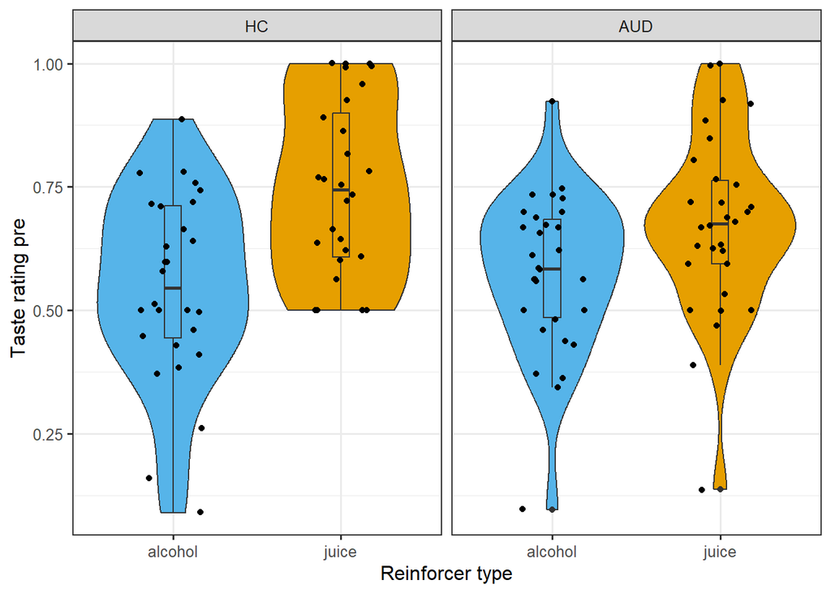

```r
fig1 <- ggplot(behav_rating, aes(reinforcer_type, y = taste1, fill=reinforcer_type)) +
  geom_violin() +
  geom_boxplot(width=0.1) +
  geom_jitter(shape=16, position=position_jitter(0.2)) +
  facet_wrap(~aud_group, scales="fixed") +
  scale_x_discrete("Reinforcer type", labels=c('alcohol', 'juice')) +
  scale_y_continuous("Taste rating pre") +
  scale_fill_manual("Reinforcer type", values = cbPalette[c(6,8)]) +
  theme_bw(base_size=12) +
  theme(legend.position = "none")

fig1
```

#### 5.4.1.2 Per group

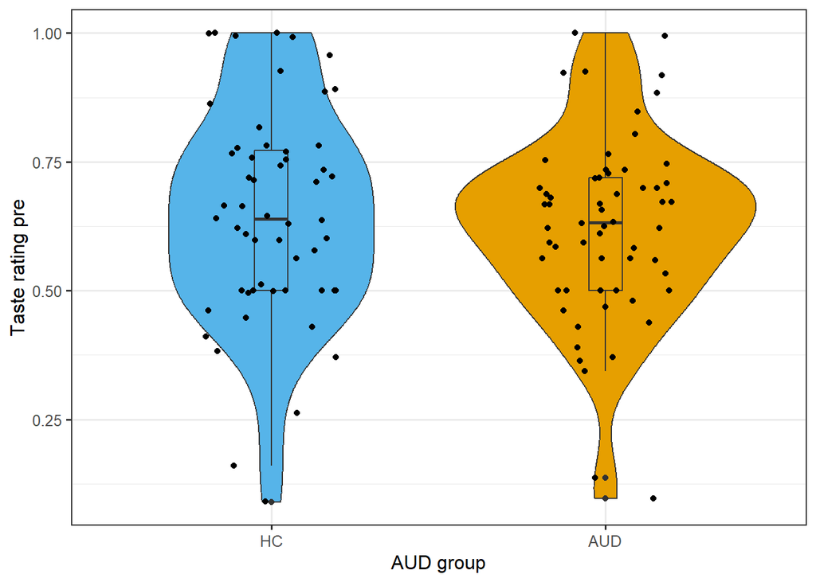

```r
fig1 <- ggplot(behav_rating, aes(aud_group, y = taste1, fill=aud_group)) +
  geom_violin() +
  geom_boxplot(width=0.1) +
  geom_jitter(shape=16, position=position_jitter(0.2)) +
  scale_x_discrete("AUD group", labels=c('HC', 'AUD')) +
  scale_y_continuous("Taste rating pre") +
  scale_fill_manual("AUD group", values = cbPalette[c(6,8)]) +
  theme_bw(base_size=12) +
  theme(legend.position = "none")

fig1
```

### 5.4.2 Tasting post

#### 5.4.2.1 Per group and reinforcer type

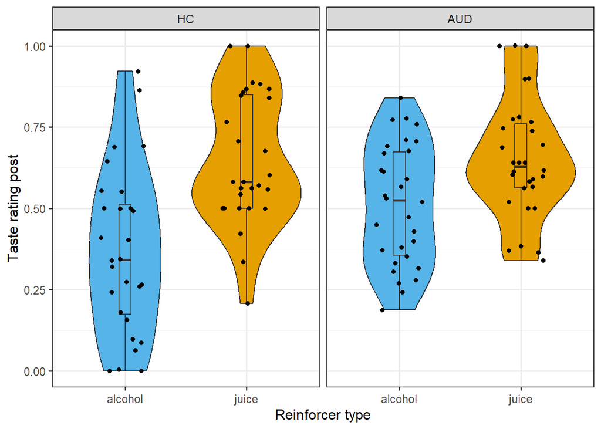

```r
fig1 <- ggplot(behav_rating, aes(reinforcer_type, y = taste2, fill=reinforcer_type)) +
  geom_violin() +
  geom_boxplot(width=0.1) +
  geom_jitter(shape=16, position=position_jitter(0.2)) +
  facet_wrap(~aud_group, scales="fixed") +
  scale_x_discrete("Reinforcer type", labels=c('alcohol', 'juice')) +
  scale_y_continuous("Taste rating post") +
  scale_fill_manual("Reinforcer type", values = cbPalette[c(6,8)]) +
  theme_bw(base_size=12) +
  theme(legend.position = "none")

fig1
```

#### 5.4.2.2 Per group

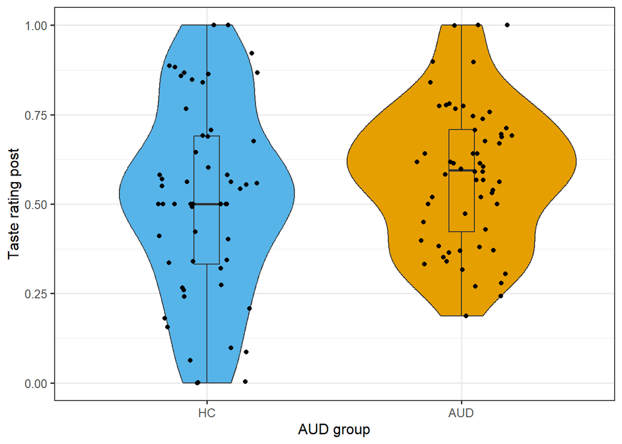

```r
fig1 <- ggplot(behav_rating, aes(aud_group, y = taste2, fill=aud_group)) +
  geom_violin() +
  geom_boxplot(width=0.1) +
  geom_jitter(shape=16, position=position_jitter(0.2)) +
  scale_x_discrete("AUD group", labels=c('HC', 'AUD')) +
  scale_y_continuous("Taste rating post") +
  scale_fill_manual("AUD group", values = cbPalette[c(6,8)]) +
  theme_bw(base_size=12) +
  theme(legend.position = "none")

fig1
```

### 5.4.3 Taste difference

#### 5.4.3.1 Per group and reinforcer type

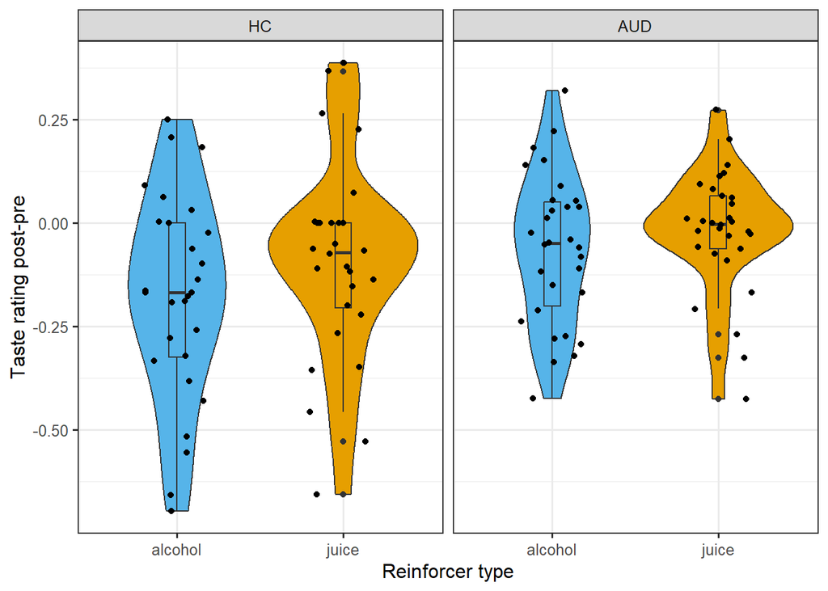

```r
fig1 <- ggplot(behav_rating, aes(reinforcer_type, y = taste_diff, fill=reinforcer_type)) +
  geom_violin() +
  geom_boxplot(width=0.1) +
  geom_jitter(shape=16, position=position_jitter(0.2)) +
  facet_wrap(~aud_group, scales="fixed") +
  scale_x_discrete("Reinforcer type", labels=c('alcohol', 'juice')) +
  scale_y_continuous("Taste rating post-pre") +
  scale_fill_manual("Reinforcer type", values = cbPalette[c(6,8)]) +
  theme_bw(base_size=12) +
  theme(legend.position = "none")

fig1
```

#### 5.4.3.2 Per group

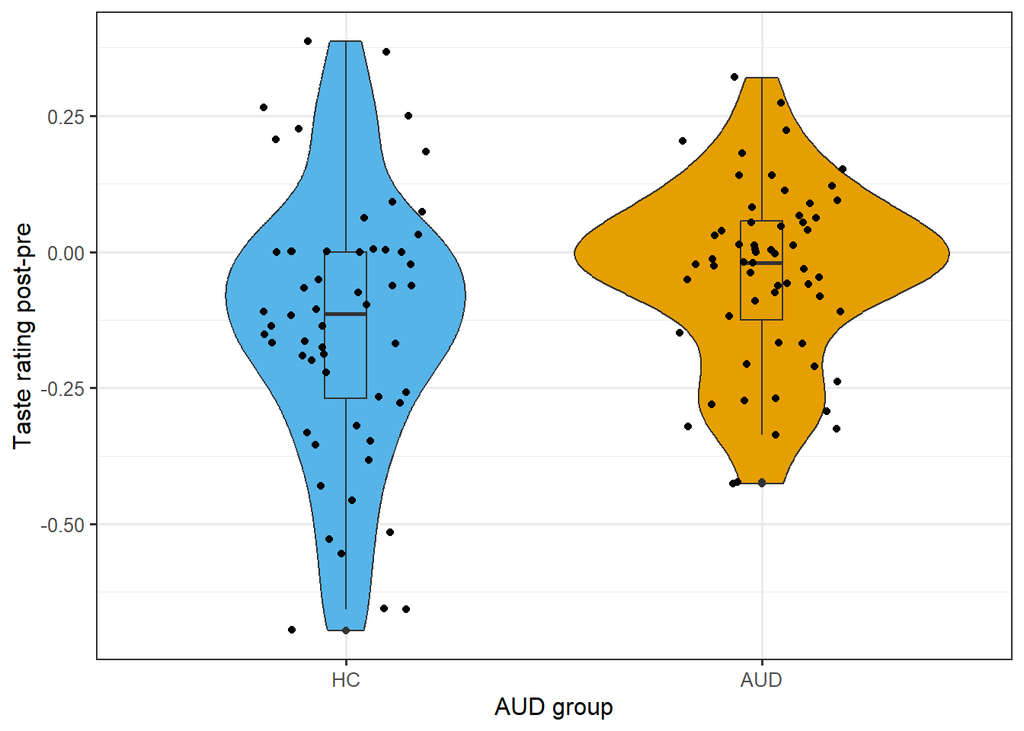

```r
fig1 <- ggplot(behav_rating, aes(aud_group, y = taste_diff, fill=aud_group)) +
  geom_violin() +
  geom_boxplot(width=0.1) +
  geom_jitter(shape=16, position=position_jitter(0.2)) +
  scale_x_discrete("AUD group", labels=c('HC', 'AUD')) +
  scale_y_continuous("Taste rating post-pre") +
  scale_fill_manual("AUD group", values = cbPalette[c(6,8)]) +
  theme_bw(base_size=12) +
  theme(legend.position = "none")

fig1
```

### 5.4.4 Craving pre

#### 5.4.4.1 Per group and reinforcer type

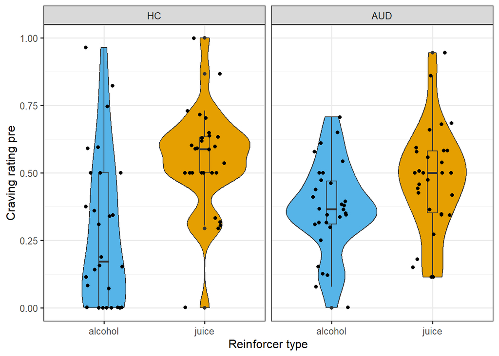

```r
fig1 <- ggplot(behav_rating, aes(reinforcer_type, y = crave1, fill=reinforcer_type)) +
  geom_violin() +
  geom_boxplot(width=0.1) +
  geom_jitter(shape=16, position=position_jitter(0.2)) +
  facet_wrap(~aud_group, scales="fixed") +
  scale_x_discrete("Reinforcer type", labels=c('alcohol', 'juice')) +
  scale_y_continuous("Craving rating pre") +
  scale_fill_manual("Reinforcer type", values = cbPalette[c(6,8)]) +
  theme_bw(base_size=12) +
  theme(legend.position = "none")

fig1
```

#### 5.4.4.2 Per group

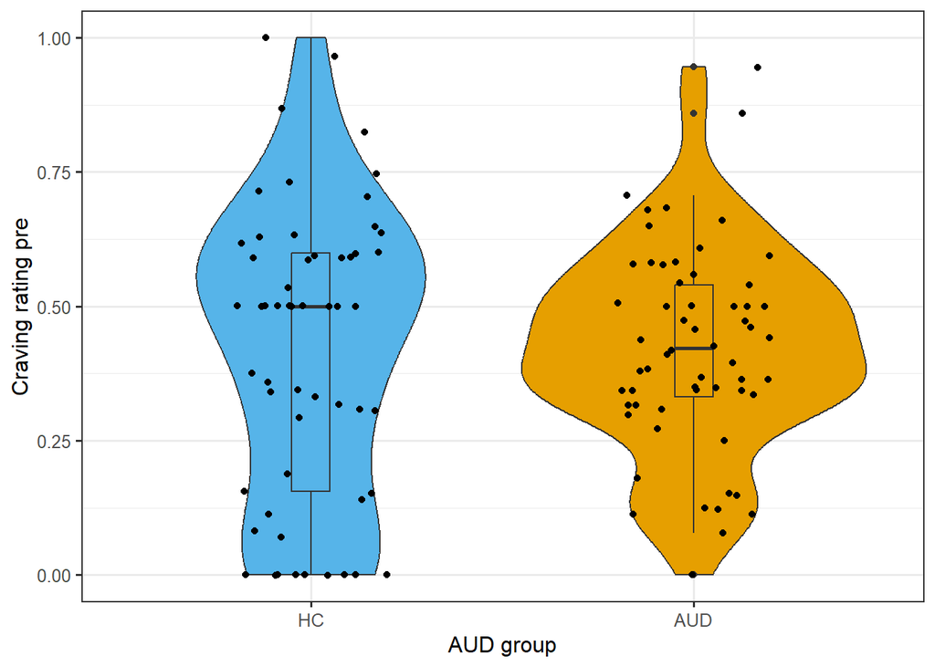

```r
fig1 <- ggplot(behav_rating, aes(aud_group, y = crave1, fill=aud_group)) +
  geom_violin() +
  geom_boxplot(width=0.1) +
  geom_jitter(shape=16, position=position_jitter(0.2)) +
  scale_x_discrete("AUD group", labels=c('HC', 'AUD')) +
  scale_y_continuous("Craving rating pre") +
  scale_fill_manual("AUD group", values = cbPalette[c(6,8)]) +
  theme_bw(base_size=12) +
  theme(legend.position = "none")

fig1
```

### 5.4.5 Craving post

#### 5.4.5.1 Per group and reinforcer type

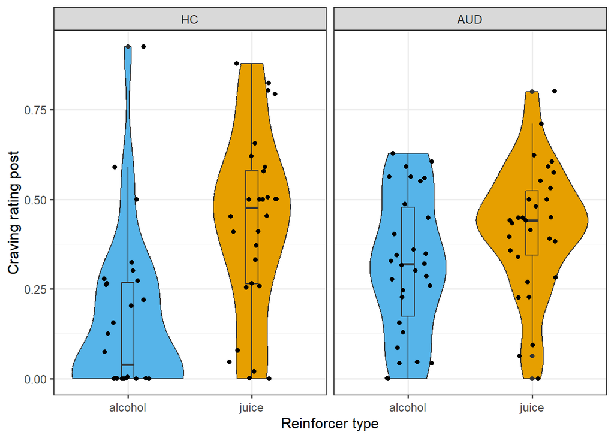

```r
fig1 <- ggplot(behav_rating, aes(reinforcer_type, y = crave2, fill=reinforcer_type)) +
  geom_violin() +
  geom_boxplot(width=0.1) +
  geom_jitter(shape=16, position=position_jitter(0.2)) +
  facet_wrap(~aud_group, scales="fixed") +
  scale_x_discrete("Reinforcer type", labels=c('alcohol', 'juice')) +
  scale_y_continuous("Craving rating post") +
  scale_fill_manual("Reinforcer type", values = cbPalette[c(6,8)]) +
  theme_bw(base_size=12) +
  theme(legend.position = "none")

fig1
```

#### 5.4.5.2 Per group

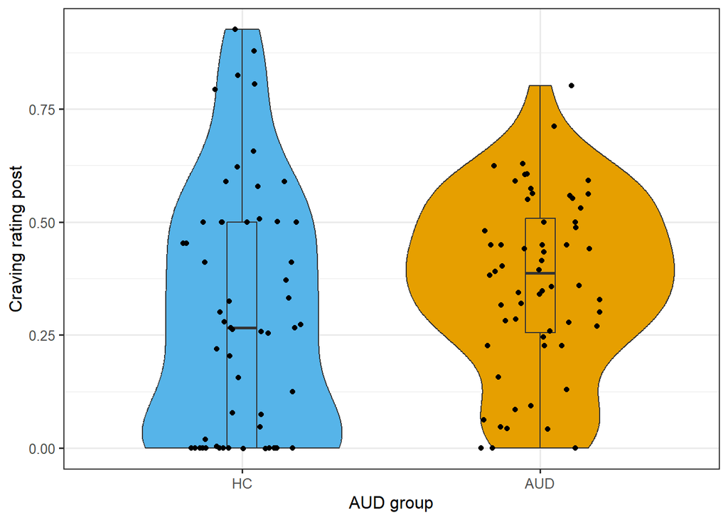

```r
fig1 <- ggplot(behav_rating, aes(aud_group, y = crave2, fill=aud_group)) +
  geom_violin() +
  geom_boxplot(width=0.1) +
  geom_jitter(shape=16, position=position_jitter(0.2)) +
  scale_x_discrete("AUD group", labels=c('HC', 'AUD')) +
  scale_y_continuous("Craving rating post") +
  scale_fill_manual("AUD group", values = cbPalette[c(6,8)]) +
  theme_bw(base_size=12) +
  theme(legend.position = "none")

fig1
```

### 5.4.6 Craving difference

#### 5.4.6.1 Per group and reinforcer type

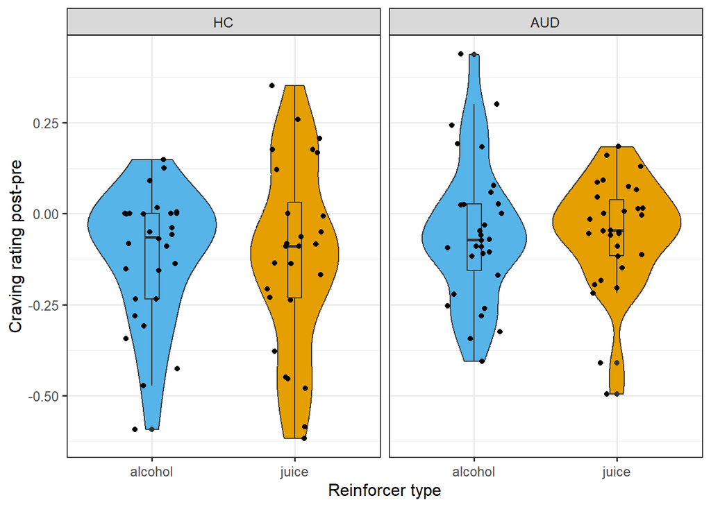

```r
fig1 <- ggplot(behav_rating, aes(reinforcer_type, y = crave_diff, fill=reinforcer_type)) +
  geom_violin() +
  geom_boxplot(width=0.1) +
  geom_jitter(shape=16, position=position_jitter(0.2)) +
  facet_wrap(~aud_group, scales="fixed") +
  scale_x_discrete("Reinforcer type", labels=c('alcohol', 'juice')) +
  scale_y_continuous("Craving rating post-pre") +
  scale_fill_manual("Reinforcer type", values = cbPalette[c(6,8)]) +
  theme_bw(base_size=12) +
  theme(legend.position = "none")

fig1
```

#### 5.4.6.2 Per group

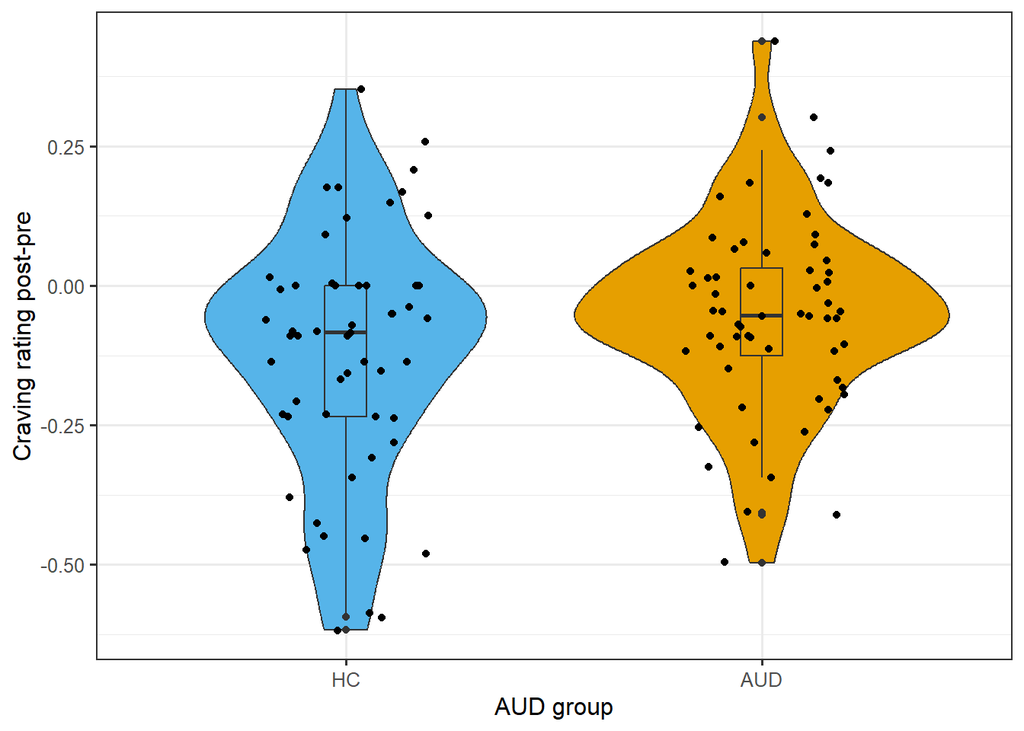

```r
fig1 <- ggplot(behav_rating, aes(aud_group, y = crave_diff, fill=aud_group)) +
  geom_violin() +
  geom_boxplot(width=0.1) +
  geom_jitter(shape=16, position=position_jitter(0.2)) +
  scale_x_discrete("AUD group", labels=c('HC', 'AUD')) +
  scale_y_continuous("Craving rating post-pre") +
  scale_fill_manual("AUD group", values = cbPalette[c(6,8)]) +
  theme_bw(base_size=12) +
  theme(legend.position = "none")

fig1
```

# 6 Correct choices

## 6.1 prepare dfs

```r
# get p correct per subject and block for linear mixed-effects regression
df_c <- behav_final %>%
  group_by(ID,reinforcer_type) %>%
  summarise_at(vars(correct), list(p_correct = mean), na.rm=T)
df_c_rating <- merge(df_c,behav_rating,by=c("ID","reinforcer_type")) # merge with demographic data for linear mixed-effects regression
df_c <- merge(df_c,redcap,by="ID") # merge with demographic data for linear mixed-effects regression

# get p correct per block and trial for plotting
df_c_block_trial <- behav_final %>%
  group_by(reinforcer_type,trial_block) %>%
  summarise_at(vars(correct), list(p_correct = mean), na.rm=T)

# get p correct per block and aud group and trial for plotting
df_c_block_trial_group <- behav_final_redcap %>%
  group_by(aud_group,reinforcer_type,trial_block) %>%
  summarise_at(vars(correct), list(p_correct = mean), na.rm=T)
```

## 6.2 Descriptive stats

```r
# per group and reinforcer type
df_c_stats <- behav_final_redcap %>%
  group_by(reinforcer_type,aud_group) %>%
  dplyr::summarise(across(c('correct'), .fns=
                   list('_mean' = mean,
                        '_sd' = sd,
                        '_min' = min,
                        '_max' = max),
                   na.rm=T))
df_c_stats
```

```
# A tibble: 4 × 6
# Groups:   reinforcer_type [2]
  reinforcer_type aud_group correct__mean correct__sd correct__min correct__max
  <fct>           <fct>             <dbl>       <dbl>        <dbl>        <dbl>
1 A               HC                0.823       0.382            0            1
2 A               AUD               0.893       0.309            0            1
3 J               HC                0.861       0.346            0            1
4 J               AUD               0.913       0.282            0            1
```

```r
df_c_stats_nan <- behav_final_redcap %>%
  group_by(reinforcer_type,aud_group) %>%
  dplyr::summarise(across(c('correct'), .fns=
                   list('_na' = ~sum(is.na(.)))))
df_c_stats_nan
```

```
# A tibble: 4 × 3
# Groups:   reinforcer_type [2]
  reinforcer_type aud_group correct__na
  <fct>           <fct>           <int>
1 A               HC                 27
2 A               AUD                24
3 J               HC                 23
4 J               AUD                27
```

```r
# per group
df_c_stats <- behav_final_redcap %>%
  group_by(aud_group) %>%
  dplyr::summarise(across(c('correct'), .fns=
                   list('_mean' = mean,
                        '_sd' = sd,
                        '_min' = min,
                        '_max' = max),
                   na.rm=T))

df_c_stats
```

```
# A tibble: 2 × 5
  aud_group correct__mean correct__sd correct__min correct__max
  <fct>             <dbl>       <dbl>        <dbl>        <dbl>
1 HC                0.842       0.365            0            1
2 AUD               0.903       0.296            0            1
```

```r
df_c_stats_nan <- behav_final_redcap %>%
  group_by(aud_group) %>%
  dplyr::summarise(across(c('correct'), .fns=
                   list('_na' = ~sum(is.na(.)))))

df_c_stats_nan
```

```
# A tibble: 2 × 2
  aud_group correct__na
  <fct>           <int>
1 HC                 50
2 AUD                51
```

```r
# per reinforcer type
df_c_stats <- behav_final_redcap %>%
  group_by(reinforcer_type) %>%
  dplyr::summarise(across(c('correct'), .fns=
                   list('_mean' = mean,
                        '_sd' = sd,
                        '_min' = min,
                        '_max' = max),
                   na.rm=T))

df_c_stats
```

```
# A tibble: 2 × 5
  reinforcer_type correct__mean correct__sd correct__min correct__max
  <fct>                   <dbl>       <dbl>        <dbl>        <dbl>
1 A                       0.859       0.348            0            1
2 J                       0.888       0.315            0            1
```

```r
df_c_stats_nan <- behav_final_redcap %>%
  group_by(reinforcer_type) %>%
  dplyr::summarise(across(c('correct'), .fns=
                   list('_na' = ~sum(is.na(.)))))

df_c_stats_nan
```

```
# A tibble: 2 × 2
  reinforcer_type correct__na
  <fct>                 <int>
1 A                        51
2 J                        50
```

```r
# overall
df_c_stats <- behav_final_redcap %>%
  dplyr::summarise(across(c('correct'), .fns=
                   list('_mean' = mean,
                        '_sd' = sd,
                        '_min' = min,
                        '_max' = max),
                   na.rm=T))

df_c_stats
```

```
  correct__mean correct__sd correct__min correct__max
1      0.873662    0.332259            0            1
```

```r
df_c_stats_nan <- behav_final_redcap %>%
  dplyr::summarise(across(c('correct'), .fns=
                   list('_na' = ~sum(is.na(.)))))

df_c_stats_nan
```

```
  correct__na
1         101
```

```r
table(behav_final_redcap$correct)
```

```
   0    1
 720 4979
```

## 6.3 Linear mixed-effects regression

### 6.3.1 AUD group

```r
m_correct_1 <- lmer(p_correct ~ 1 + reinforcer_type*aud_group + (1 | ID), data=df_c, control=lmerControl(calc.derivs=FALSE), REML=F)
#m_correct_2 <- lmer(p_correct ~ 1 + reinforcer_type*aud_group + (1 + reinforcer_type || ID), data=df_c, control=lmerControl(calc.derivs=FALSE), REML=F)
#m_correct_3 <- lmer(p_correct ~ 1 + reinforcer_type*aud_group + (1 + reinforcer_type | ID), data=df_c, control=lmerControl(calc.derivs=FALSE), REML=F)

#anova(m_correct_1,m_correct_2,m_correct_3)

tab_model(m_correct_1,
          dv.labels=c("m_correct"), digits=3, digits.re=2,
          show.se=TRUE, show.stat=TRUE, show.df=TRUE, show.ci=FALSE,CSS = css_theme("cells"))
```

|  | m_correct |  |  |  |  |
| --- | --- | --- | --- | --- | --- |
| Predictors | Estimates | std. Error | Statistic | p | df |
| (Intercept) | 0.861 | 0.026 | 32.989 | **<0.001** | 110.000 |
| reinforcer type2 | -0.038 | 0.028 | -1.334 | 0.185 | 110.000 |
| aud group2 | 0.052 | 0.036 | 1.423 | 0.158 | 110.000 |
| reinforcer type2 × aud group2 | 0.017 | 0.039 | 0.428 | 0.670 | 110.000 |
| Random Effects |  |  |  |  |  |
| σ<sup>2</sup> | 0.01 |  |  |  |  |
| τ<sub>00</sub> <sub>ID</sub> | 0.01 |  |  |  |  |
| ICC | 0.41 |  |  |  |  |
| N <sub>ID</sub> | 58 |  |  |  |  |
| Observations | 116 |  |  |  |  |
| Marginal R<sup>2</sup> / Conditional R<sup>2</sup> | 0.056 / 0.443 |  |  |  |  |

We cannot include reinforcer type as random effect as the model would be unidentifiable.

We find - n.s. effects.

### 6.3.2 AUD criteria

```r
m_correct_1_audsum <- lmer(p_correct ~ 1 + reinforcer_type*aud_sum + (1 | ID), data=df_c, control=lmerControl(calc.derivs=FALSE), REML=F)
#m_correct_2_audsum <- lmer(p_correct ~ 1 + reinforcer_type*aud_sum + (1 + reinforcer_type || ID), data=df_c, control=lmerControl(calc.derivs=FALSE), REML=F)
#m_correct_3_audsum <- lmer(p_correct ~ 1 + reinforcer_type*aud_sum + (1 + reinforcer_type | ID), data=df_c, control=lmerControl(calc.derivs=FALSE), REML=F)

#anova(m_correct_1_audsum,m_correct_2_audsum,m_correct_3_audsum)

tab_model(m_correct_1_audsum,
          dv.labels=c("m_correct"), digits=3, digits.re=2,
          show.se=TRUE, show.stat=TRUE, show.df=TRUE, show.ci=FALSE,CSS = css_theme("cells"))
```

|  | m_correct |  |  |  |  |
| --- | --- | --- | --- | --- | --- |
| Predictors | Estimates | std. Error | Statistic | p | df |
| (Intercept) | 0.874 | 0.025 | 34.792 | **<0.001** | 110.000 |
| reinforcer type2 | -0.048 | 0.027 | -1.778 | 0.078 | 110.000 |
| aud sum | 0.006 | 0.008 | 0.761 | 0.448 | 110.000 |
| reinforcer type2 × aud sum | 0.008 | 0.008 | 1.015 | 0.312 | 110.000 |
| Random Effects |  |  |  |  |  |
| σ<sup>2</sup> | 0.01 |  |  |  |  |
| τ<sub>00</sub> <sub>ID</sub> | 0.01 |  |  |  |  |
| ICC | 0.43 |  |  |  |  |
| N <sub>ID</sub> | 58 |  |  |  |  |
| Observations | 116 |  |  |  |  |
| Marginal R<sup>2</sup> / Conditional R<sup>2</sup> | 0.044 / 0.451 |  |  |  |  |

We cannot include reinforcer type as random effect as the model would be unidentifiable.

We find - n.s. effects.

### 6.3.3 AUDIT criteria

```r
m_correct_1_auditsum <- lmer(p_correct ~ 1 + reinforcer_type*audit_sum + (1 | ID), data=df_c, control=lmerControl(calc.derivs=FALSE), REML=F)
#m_correct_2_auditsum <- lmer(p_correct ~ 1 + reinforcer_type*audit_sum + (1 + reinforcer_type || ID), data=df_c, control=lmerControl(calc.derivs=FALSE), REML=F)
#m_correct_3_auditsum <- lmer(p_correct ~ 1 + reinforcer_type*audit_sum + (1 + reinforcer_type | ID), data=df_c, control=lmerControl(calc.derivs=FALSE), REML=F)

#anova(m_correct_1_auditsum,m_correct_2_auditsum,m_correct_3_auditsum)

tab_model(m_correct_1_auditsum,
          dv.labels=c("m_correct"), digits=3, digits.re=2,
          show.se=TRUE, show.stat=TRUE, show.df=TRUE, show.ci=FALSE,CSS = css_theme("cells"))
```

|  | m_correct |  |  |  |  |
| --- | --- | --- | --- | --- | --- |
| Predictors | Estimates | std. Error | Statistic | p | df |
| (Intercept) | 0.871 | 0.032 | 27.486 | **<0.001** | 110.000 |
| reinforcer type2 | -0.045 | 0.034 | -1.338 | 0.184 | 110.000 |
| audit sum | 0.002 | 0.003 | 0.664 | 0.508 | 110.000 |
| reinforcer type2 × audit sum | 0.002 | 0.003 | 0.588 | 0.557 | 110.000 |
| Random Effects |  |  |  |  |  |
| σ<sup>2</sup> | 0.01 |  |  |  |  |
| τ<sub>00</sub> <sub>ID</sub> | 0.01 |  |  |  |  |
| ICC | 0.43 |  |  |  |  |
| N <sub>ID</sub> | 58 |  |  |  |  |
| Observations | 116 |  |  |  |  |
| Marginal R<sup>2</sup> / Conditional R<sup>2</sup> | 0.028 / 0.444 |  |  |  |  |

We cannot include reinforcer type as random effect as the model would be unidentifiable.

We find - n.s. effects.

## 6.4 Exploratory: Logistic mixed-effects regression

### 6.4.1 AUD group

```r
m_correct_log_1 <- glmer(correct ~ 1 + reinforcer_type*aud_group + (1 | ID), data=behav_final_redcap, family = binomial, control=glmerControl(calc.derivs=FALSE))
m_correct_log_2 <- glmer(correct ~ 1 + reinforcer_type*aud_group + (1 + reinforcer_type || ID), data=behav_final_redcap, family = binomial, control=glmerControl(calc.derivs=FALSE))
m_correct_log_3 <- glmer(correct ~ 1 + reinforcer_type*aud_group + (1 + reinforcer_type | ID), data=behav_final_redcap, family = binomial, control=glmerControl(calc.derivs=FALSE))

anova(m_correct_log_1,m_correct_log_2)
```

```
Data: behav_final_redcap
Models:
m_correct_log_1: correct ~ 1 + reinforcer_type * aud_group + (1 | ID)
m_correct_log_2: correct ~ 1 + reinforcer_type * aud_group + (1 + reinforcer_type || ID)
                npar    AIC    BIC  logLik deviance  Chisq Df Pr(>Chisq)
m_correct_log_1    5 3794.9 3828.1 -1892.5   3784.9
m_correct_log_2    8 3674.3 3727.5 -1829.2   3658.3 126.56  3  < 2.2e-16 ***
---
Signif. codes:  0 '***' 0.001 '**' 0.01 '*' 0.05 '.' 0.1 ' ' 1
```

```r
anova(m_correct_log_2,m_correct_log_3)
```

```
Data: behav_final_redcap
Models:
m_correct_log_3: correct ~ 1 + reinforcer_type * aud_group + (1 + reinforcer_type | ID)
m_correct_log_2: correct ~ 1 + reinforcer_type * aud_group + (1 + reinforcer_type || ID)
                npar    AIC    BIC  logLik deviance Chisq Df Pr(>Chisq)
m_correct_log_3    7 3672.3 3718.9 -1829.2   3658.3
m_correct_log_2    8 3674.3 3727.5 -1829.2   3658.3     0  1          1
```

```r
tab_model(m_correct_log_2,
          dv.labels=c("m_correct_log"), digits=3, digits.re=2,
          show.se=TRUE, show.stat=TRUE, show.df=TRUE, show.ci=FALSE,CSS = css_theme("cells"))
```

|  | m_correct_log |  |  |  |  |
| --- | --- | --- | --- | --- | --- |
| Predictors | Odds Ratios | std. Error | Statistic | p | df |
| (Intercept) | 11.944 | 3.693 | 8.022 | **<0.001** | Inf |
| reinforcer type2 | 0.663 | 0.211 | -1.290 | 0.197 | Inf |
| aud group2 | 2.004 | 0.880 | 1.582 | 0.114 | Inf |
| reinforcer type2 × aud group2 | 1.012 | 0.463 | 0.027 | 0.979 | Inf |
| Random Effects |  |  |  |  |  |
| σ<sup>2</sup> | 3.29 |  |  |  |  |
| τ<sub>00</sub> <sub>ID</sub> | 1.05 |  |  |  |  |
| τ<sub>11</sub> <sub>ID.reinforcer_typeA</sub> | 0.88 |  |  |  |  |
| τ<sub>11</sub> <sub>ID.reinforcer_typeJ</sub> | 1.22 |  |  |  |  |
| ρ<sub>01</sub> |  |  |  |  |  |
| ρ<sub>01</sub> |  |  |  |  |  |
| ICC | 0.24 |  |  |  |  |
| N <sub>ID</sub> | 58 |  |  |  |  |
| Observations | 5699 |  |  |  |  |
| Marginal R<sup>2</sup> / Conditional R<sup>2</sup> | 0.036 / 0.269 |  |  |  |  |

### 6.4.2 AUD criteria

```r
m_correct_log_1_audsum <- glmer(correct ~ 1 + reinforcer_type*aud_sum + (1 | ID), data=behav_final_redcap, family = binomial, control=glmerControl(calc.derivs=FALSE))
m_correct_log_2_audsum <- glmer(correct ~ 1 + reinforcer_type*aud_sum + (1 + reinforcer_type || ID), data=behav_final_redcap, family = binomial, control=glmerControl(calc.derivs=FALSE))
m_correct_log_3_audsum <- glmer(correct ~ 1 + reinforcer_type*aud_sum + (1 + reinforcer_type | ID), data=behav_final_redcap, family = binomial, control=glmerControl(calc.derivs=FALSE))

anova(m_correct_log_1_audsum,m_correct_log_2_audsum)
```

```
Data: behav_final_redcap
Models:
m_correct_log_1_audsum: correct ~ 1 + reinforcer_type * aud_sum + (1 | ID)
m_correct_log_2_audsum: correct ~ 1 + reinforcer_type * aud_sum + (1 + reinforcer_type || ID)
                       npar    AIC    BIC  logLik deviance  Chisq Df Pr(>Chisq)
m_correct_log_1_audsum    5 3791.9 3825.2 -1891.0   3781.9
m_correct_log_2_audsum    8 3675.6 3728.8 -1829.8   3659.6 122.32  3  < 2.2e-16

m_correct_log_1_audsum
m_correct_log_2_audsum ***
---
Signif. codes:  0 '***' 0.001 '**' 0.01 '*' 0.05 '.' 0.1 ' ' 1
```

```r
anova(m_correct_log_2_audsum,m_correct_log_3_audsum)
```

```
Data: behav_final_redcap
Models:
m_correct_log_3_audsum: correct ~ 1 + reinforcer_type * aud_sum + (1 + reinforcer_type | ID)
m_correct_log_2_audsum: correct ~ 1 + reinforcer_type * aud_sum + (1 + reinforcer_type || ID)
                       npar    AIC    BIC  logLik deviance Chisq Df Pr(>Chisq)
m_correct_log_3_audsum    7 3673.6 3720.2 -1829.8   3659.6
m_correct_log_2_audsum    8 3675.6 3728.8 -1829.8   3659.6     0  1          1
```

```r
tab_model(m_correct_log_2_audsum,
          dv.labels=c("m_correct_log"), digits=3, digits.re=2,
          show.se=TRUE, show.stat=TRUE, show.df=TRUE, show.ci=FALSE,CSS = css_theme("cells"))
```

|  | m_correct_log |  |  |  |  |
| --- | --- | --- | --- | --- | --- |
| Predictors | Odds Ratios | std. Error | Statistic | p | df |
| (Intercept) | 13.800 | 4.194 | 8.637 | **<0.001** | Inf |
| reinforcer type2 | 0.609 | 0.188 | -1.609 | 0.108 | Inf |
| aud sum | 1.102 | 0.106 | 1.011 | 0.312 | Inf |
| reinforcer type2 × aud sum | 1.040 | 0.103 | 0.397 | 0.692 | Inf |
| Random Effects |  |  |  |  |  |
| σ<sup>2</sup> | 3.29 |  |  |  |  |
| τ<sub>00</sub> <sub>ID</sub> | 1.12 |  |  |  |  |
| τ<sub>11</sub> <sub>ID.reinforcer_typeA</sub> | 0.82 |  |  |  |  |
| τ<sub>11</sub> <sub>ID.reinforcer_typeJ</sub> | 1.23 |  |  |  |  |
| ρ<sub>01</sub> |  |  |  |  |  |
| ρ<sub>01</sub> |  |  |  |  |  |
| ICC | 0.25 |  |  |  |  |
| N <sub>ID</sub> | 58 |  |  |  |  |
| Observations | 5699 |  |  |  |  |
| Marginal R<sup>2</sup> / Conditional R<sup>2</sup> | 0.026 / 0.273 |  |  |  |  |

We find - n.s. effects.

### 6.4.3 AUDIT criteria

```r
m_correct_log_1_auditsum <- glmer(correct ~ 1 + reinforcer_type*audit_sum + (1 | ID), data=behav_final_redcap, family = binomial, control=glmerControl(calc.derivs=FALSE))
m_correct_log_2_auditsum <- glmer(correct ~ 1 + reinforcer_type*audit_sum + (1 + reinforcer_type || ID), data=behav_final_redcap, family = binomial, control=glmerControl(calc.derivs=FALSE))
m_correct_log_3_auditsum <- glmer(correct ~ 1 + reinforcer_type*audit_sum + (1 + reinforcer_type | ID), data=behav_final_redcap, family = binomial, control=glmerControl(calc.derivs=FALSE))

anova(m_correct_log_1_auditsum,m_correct_log_2_auditsum)
```

```
Data: behav_final_redcap
Models:
m_correct_log_1_auditsum: correct ~ 1 + reinforcer_type * audit_sum + (1 | ID)
m_correct_log_2_auditsum: correct ~ 1 + reinforcer_type * audit_sum + (1 + reinforcer_type || ID)
                         npar    AIC    BIC  logLik deviance  Chisq Df
m_correct_log_1_auditsum    5 3796.1 3829.3 -1893.0   3786.1
m_correct_log_2_auditsum    8 3676.8 3730.0 -1830.4   3660.8 125.28  3
                         Pr(>Chisq)
m_correct_log_1_auditsum
m_correct_log_2_auditsum  < 2.2e-16 ***
---
Signif. codes:  0 '***' 0.001 '**' 0.01 '*' 0.05 '.' 0.1 ' ' 1
```

```r
anova(m_correct_log_2_auditsum,m_correct_log_3_auditsum)
```

```
Data: behav_final_redcap
Models:
m_correct_log_3_auditsum: correct ~ 1 + reinforcer_type * audit_sum + (1 + reinforcer_type | ID)
m_correct_log_2_auditsum: correct ~ 1 + reinforcer_type * audit_sum + (1 + reinforcer_type || ID)
                         npar    AIC    BIC  logLik deviance Chisq Df
m_correct_log_3_auditsum    7 3674.8 3721.3 -1830.4   3660.8
m_correct_log_2_auditsum    8 3676.8 3730.0 -1830.4   3660.8 6e-04  1
                         Pr(>Chisq)
m_correct_log_3_auditsum
m_correct_log_2_auditsum     0.9803
```

```r
tab_model(m_correct_log_2_auditsum,
          dv.labels=c("m_correct_log"), digits=3, digits.re=2,
          show.se=TRUE, show.stat=TRUE, show.df=TRUE, show.ci=FALSE,CSS = css_theme("cells"))
```

|  | m_correct_log |  |  |  |  |
| --- | --- | --- | --- | --- | --- |
| Predictors | Odds Ratios | std. Error | Statistic | p | df |
| (Intercept) | 12.558 | 4.770 | 6.662 | **<0.001** | Inf |
| reinforcer type2 | 0.673 | 0.261 | -1.020 | 0.308 | Inf |
| audit sum | 1.034 | 0.035 | 0.994 | 0.320 | Inf |
| reinforcer type2 × audit sum | 0.998 | 0.035 | -0.047 | 0.962 | Inf |
| Random Effects |  |  |  |  |  |
| σ<sup>2</sup> | 3.29 |  |  |  |  |
| τ<sub>00</sub> <sub>ID</sub> | 1.10 |  |  |  |  |
| τ<sub>11</sub> <sub>ID.reinforcer_typeA</sub> | 0.90 |  |  |  |  |
| τ<sub>11</sub> <sub>ID.reinforcer_typeJ</sub> | 1.26 |  |  |  |  |
| ρ<sub>01</sub> |  |  |  |  |  |
| ρ<sub>01</sub> |  |  |  |  |  |
| ICC | 0.25 |  |  |  |  |
| N <sub>ID</sub> | 58 |  |  |  |  |
| Observations | 5699 |  |  |  |  |
| Marginal R<sup>2</sup> / Conditional R<sup>2</sup> | 0.020 / 0.265 |  |  |  |  |

## 6.5 Plotting

### 6.5.1 Per group and reinforcer type

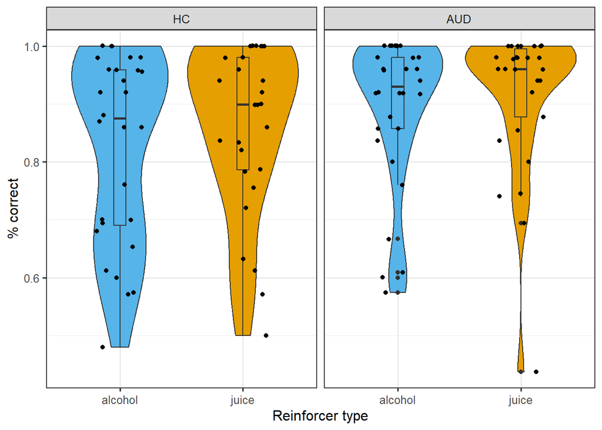

```r
fig1 <- ggplot(df_c, aes(reinforcer_type, y = p_correct, fill=reinforcer_type)) +
  geom_violin() +
  geom_boxplot(width=0.1) +
  geom_jitter(shape=16, position=position_jitter(0.2)) +
  facet_wrap(~aud_group, scales="fixed") +
  scale_x_discrete("Reinforcer type", labels=c('alcohol', 'juice')) +
  scale_y_continuous("% correct") +
  scale_fill_manual("Reinforcer type", values = cbPalette[c(6,8)]) +
  theme_bw(base_size=12) +
  theme(legend.position = "none")

fig1
```

### 6.5.2 Per reinforcer type

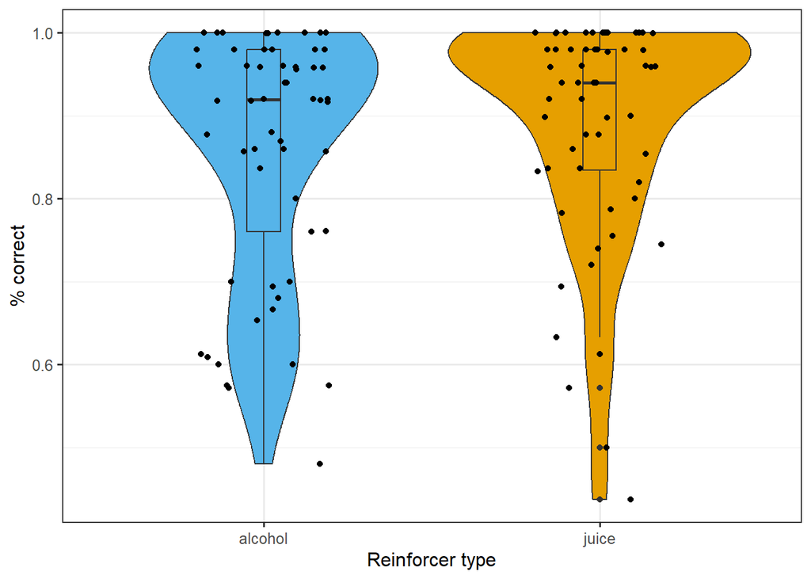

```r
fig1 <- ggplot(df_c, aes(reinforcer_type, y = p_correct, fill=reinforcer_type)) +
  geom_violin() +
  geom_boxplot(width=0.1) +
  geom_jitter(shape=16, position=position_jitter(0.2)) +
  #facet_wrap(~aud_group, scales="fixed") +
  scale_x_discrete("Reinforcer type", labels=c('alcohol', 'juice')) +
  scale_y_continuous("% correct") +
  scale_fill_manual("Reinforcer type", values = cbPalette[c(6,8)]) +
  theme_bw(base_size=12) +
  theme(legend.position = "none")

fig1
```

### 6.5.3 Correct choices over course of task

#### 6.5.3.1 Per block

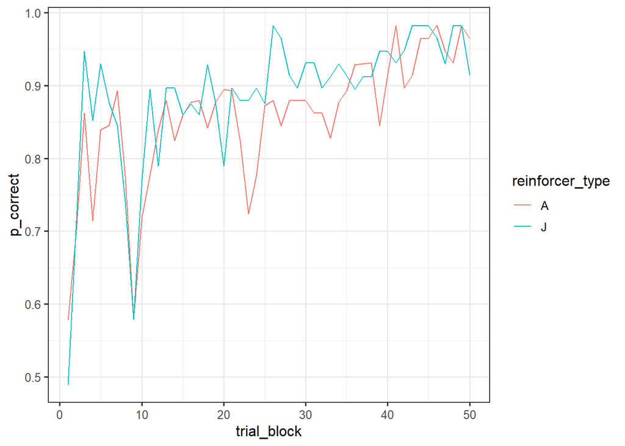

```r
fig2 <- ggplot(df_c_block_trial, aes(x=trial_block, y=p_correct, group=reinforcer_type)) +
  geom_line(aes(color=reinforcer_type)) +
  scale_fill_manual("Reinforcer type", values = cbPalette[c(1,2)]) +
  theme_bw(base_size=12)

fig2
```

- P correct per block and trial across subjects.
- Drops most likely due to probabilistic events - same across all subjects, different across versions, but partially overlapping (e.g. 7,8 in version A, 7,8,9 in version B).
- p_correct quickly rises above 0.5 –> subjects chose rewarded card more often –> rewards aren’t generally aversive
- p_correct is generally higher for juice vs. alcohol reward
- no string ceiling effect, but p_correct rises quickly

#### 6.5.3.2 Per block and aud group

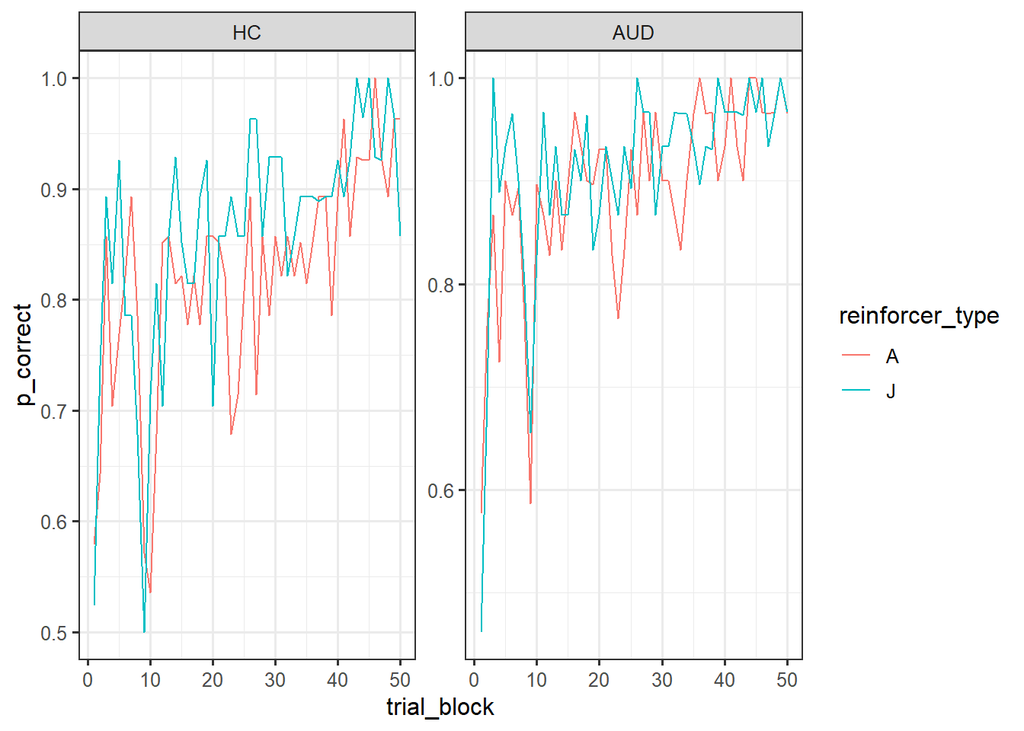

```r
fig3 <- ggplot(df_c_block_trial_group, aes(x=trial_block, y=p_correct, group=reinforcer_type)) +
  geom_line(aes(color=reinforcer_type)) +
  scale_fill_manual("Reinforcer type", values = cbPalette[c(1,2)]) +
  theme_bw(base_size=12) +
  facet_wrap(~aud_group, scales="free_y")

fig3
```

#### 6.5.3.3 Per ID and trial bin

[figure not shown]

```r
fig2 <- ggplot(df_c_ID_block_trialbin, aes(x=trial_bin, y=p_correct, group=reinforcer_type)) +
  geom_line(aes(color=reinforcer_type)) +
  #scale_fill_manual("Reinforcer type", values = cbPalette[c(1,2)]) +
  theme_bw(base_size=20) +
  facet_wrap(~ID, scales="fixed")

fig2
```

```r
#ggsave("C:/Users/musialm/OneDrive - Charité - Universitätsmedizin Berlin/PhD/04_B01/ILT/WP2_ILT_CODE/Stan Modeling/test.jpg", width =30, height = 20,limitsize = FALSE)
```

# 7 Association correct choices & ratings

## 7.1 Linear mixed-effects regression taste rating

```r
m_c_taste1=lmer(p_correct~taste1 + (1 | ID),
                data=df_c_rating,
                control=lmerControl(calc.derivs=FALSE))

tab_model(m_c_taste1,
          dv.labels=c("m_c_taste1"), digits=3, digits.re=2,
          show.se=TRUE, show.stat=TRUE, show.df=TRUE, show.ci=FALSE,CSS = css_theme("cells"))
```

|  | m_c_taste1 |  |  |  |  |
| --- | --- | --- | --- | --- | --- |
| Predictors | Estimates | std. Error | Statistic | p | df |
| (Intercept) | 0.860 | 0.043 | 19.989 | **<0.001** | 112.000 |
| taste1 | 0.021 | 0.063 | 0.332 | 0.740 | 112.000 |
| Random Effects |  |  |  |  |  |
| σ<sup>2</sup> | 0.01 |  |  |  |  |
| τ<sub>00</sub> <sub>ID</sub> | 0.01 |  |  |  |  |
| ICC | 0.43 |  |  |  |  |
| N <sub>ID</sub> | 58 |  |  |  |  |
| Observations | 116 |  |  |  |  |
| Marginal R<sup>2</sup> / Conditional R<sup>2</sup> | 0.001 / 0.433 |  |  |  |  |

```r
m_c_taste2=lmer(p_correct~taste2 + (1 | ID),
                data=df_c_rating,
                control=lmerControl(calc.derivs=FALSE))

tab_model(m_c_taste2,
          dv.labels=c("m_c_taste2"), digits=3, digits.re=2,
          show.se=TRUE, show.stat=TRUE, show.df=TRUE, show.ci=FALSE,CSS = css_theme("cells"))
```

|  | m_c_taste2 |  |  |  |  |
| --- | --- | --- | --- | --- | --- |
| Predictors | Estimates | std. Error | Statistic | p | df |
| (Intercept) | 0.831 | 0.033 | 25.224 | **<0.001** | 112.000 |
| taste2 | 0.077 | 0.052 | 1.467 | 0.145 | 112.000 |
| Random Effects |  |  |  |  |  |
| σ<sup>2</sup> | 0.01 |  |  |  |  |
| τ<sub>00</sub> <sub>ID</sub> | 0.01 |  |  |  |  |
| ICC | 0.47 |  |  |  |  |
| N <sub>ID</sub> | 58 |  |  |  |  |
| Observations | 116 |  |  |  |  |
| Marginal R<sup>2</sup> / Conditional R<sup>2</sup> | 0.016 / 0.474 |  |  |  |  |

```r
m_c_taste_diff=lmer(p_correct~taste_diff + (1 | ID),
                data=df_c_rating,
                control=lmerControl(calc.derivs=FALSE))

tab_model(m_c_taste_diff,
          dv.labels=c("m_c_taste_diff"), digits=3, digits.re=2,
          show.se=TRUE, show.stat=TRUE, show.df=TRUE, show.ci=FALSE,CSS = css_theme("cells"))
```

|  | m_c_taste_diff |  |  |  |  |
| --- | --- | --- | --- | --- | --- |
| Predictors | Estimates | std. Error | Statistic | p | df |
| (Intercept) | 0.880 | 0.017 | 52.500 | **<0.001** | 112.000 |
| taste diff | 0.077 | 0.061 | 1.271 | 0.206 | 112.000 |
| Random Effects |  |  |  |  |  |
| σ<sup>2</sup> | 0.01 |  |  |  |  |
| τ<sub>00</sub> <sub>ID</sub> | 0.01 |  |  |  |  |
| ICC | 0.44 |  |  |  |  |
| N <sub>ID</sub> | 58 |  |  |  |  |
| Observations | 116 |  |  |  |  |
| Marginal R<sup>2</sup> / Conditional R<sup>2</sup> | 0.013 / 0.444 |  |  |  |  |

## 7.2 Linear mixed-effects regression craving rating

```r
m_c_crave1=lmer(p_correct~crave1 + (1 | ID),
                data=df_c_rating,
                control=lmerControl(calc.derivs=FALSE))

tab_model(m_c_crave1,
          dv.labels=c("m_c_crave1"), digits=3, digits.re=2,
          show.se=TRUE, show.stat=TRUE, show.df=TRUE, show.ci=FALSE,CSS = css_theme("cells"))
```

|  | m_c_crave1 |  |  |  |  |
| --- | --- | --- | --- | --- | --- |
| Predictors | Estimates | std. Error | Statistic | p | df |
| (Intercept) | 0.853 | 0.028 | 30.834 | **<0.001** | 112.000 |
| crave1 | 0.049 | 0.054 | 0.899 | 0.370 | 112.000 |
| Random Effects |  |  |  |  |  |
| σ<sup>2</sup> | 0.01 |  |  |  |  |
| τ<sub>00</sub> <sub>ID</sub> | 0.01 |  |  |  |  |
| ICC | 0.43 |  |  |  |  |
| N <sub>ID</sub> | 58 |  |  |  |  |
| Observations | 116 |  |  |  |  |
| Marginal R<sup>2</sup> / Conditional R<sup>2</sup> | 0.006 / 0.436 |  |  |  |  |

```r
m_c_crave2=lmer(p_correct~crave2 + (1 | ID),
                data=df_c_rating,
                control=lmerControl(calc.derivs=FALSE))

tab_model(m_c_crave2,
          dv.labels=c("m_c_crave2"), digits=3, digits.re=2,
          show.se=TRUE, show.stat=TRUE, show.df=TRUE, show.ci=FALSE,CSS = css_theme("cells"))
```

|  | m_c_crave2 |  |  |  |  |
| --- | --- | --- | --- | --- | --- |
| Predictors | Estimates | std. Error | Statistic | p | df |
| (Intercept) | 0.858 | 0.024 | 35.941 | **<0.001** | 112.000 |
| crave2 | 0.046 | 0.053 | 0.871 | 0.386 | 112.000 |
| Random Effects |  |  |  |  |  |
| σ<sup>2</sup> | 0.01 |  |  |  |  |
| τ<sub>00</sub> <sub>ID</sub> | 0.01 |  |  |  |  |
| ICC | 0.45 |  |  |  |  |
| N <sub>ID</sub> | 58 |  |  |  |  |
| Observations | 116 |  |  |  |  |
| Marginal R<sup>2</sup> / Conditional R<sup>2</sup> | 0.006 / 0.449 |  |  |  |  |

```r
m_c_crave_diff=lmer(p_correct~crave_diff + (1 | ID),
                data=df_c_rating,
                control=lmerControl(calc.derivs=FALSE))

tab_model(m_c_crave_diff,
          dv.labels=c("m_c_crave_diff"), digits=3, digits.re=2,
          show.se=TRUE, show.stat=TRUE, show.df=TRUE, show.ci=FALSE,CSS = css_theme("cells"))
```

|  | m_c_crave_diff |  |  |  |  |
| --- | --- | --- | --- | --- | --- |
| Predictors | Estimates | std. Error | Statistic | p | df |
| (Intercept) | 0.873 | 0.017 | 51.485 | **<0.001** | 112.000 |
| crave diff | -0.004 | 0.068 | -0.060 | 0.952 | 112.000 |
| Random Effects |  |  |  |  |  |
| σ<sup>2</sup> | 0.01 |  |  |  |  |
| τ<sub>00</sub> <sub>ID</sub> | 0.01 |  |  |  |  |
| ICC | 0.43 |  |  |  |  |
| N <sub>ID</sub> | 58 |  |  |  |  |
| Observations | 116 |  |  |  |  |
| Marginal R<sup>2</sup> / Conditional R<sup>2</sup> | 0.000 / 0.426 |  |  |  |  |

# 8 Win-Stay behavior: Repeating the same action that was rewarded in previous trial

## 8.1 Prepare dfs

```r
# get p correct per subject and block for linear mixed-effects regression
df_win_stay <- behav_final %>%
  group_by(ID,reinforcer_type,na.rm=T) %>%
  summarise_at(vars(stay,win_stay), list(p = mean), na.rm=T) %>%
  na.omit()
df_win_stay <- merge(df_win_stay,redcap,by="ID") # merge with demographic data for linear mixed-effects

# get p correct per block and trial for plotting
df_win_stay_trial <- behav_final %>%
  group_by(reinforcer_type,trial_block) %>%
  summarise_at(vars(win_stay), list(p = mean), na.rm=T)

# get p correct per block and aud group and trial for plotting
df_win_stay_trial_group <- behav_final_redcap %>%
  group_by(aud_group,reinforcer_type,trial_block) %>%
  summarise_at(vars(win_stay), list(p = mean), na.rm=T)
```

## 8.2 Linear mixed-effects regression win_stay

### 8.2.1 AUD group

```r
m_win_stay_1=lmer(win_stay_p~reinforcer_type*aud_group + (1 | ID),
                data=df_win_stay,
                control=lmerControl(calc.derivs=FALSE))
#m_win_stay_2=lmer(win_stay_p~reinforcer_type*aud_group + (1 + reinforcer_type || ID),
#                data=df_win_stay,
#                control=lmerControl(calc.derivs=FALSE))
#m_win_stay_3=lmer(win_stay_p~reinforcer_type*aud_group + (1 + reinforcer_type | ID),
#                data=df_win_stay,
#                control=lmerControl(calc.derivs=FALSE))
#anova(m_win_stay_1,m_win_stay_2,m_win_stay_3)

tab_model(m_win_stay_1,
          dv.labels=c("m_stay"), digits=3, digits.re=2,
          show.se=TRUE, show.stat=TRUE, show.df=TRUE, show.ci=FALSE,CSS = css_theme("cells"))
```

|  | m_stay |  |  |  |  |
| --- | --- | --- | --- | --- | --- |
| Predictors | Estimates | std. Error | Statistic | p | df |
| (Intercept) | 0.581 | 0.022 | 26.581 | **<0.001** | 110.000 |
| reinforcer type2 | -0.050 | 0.022 | -2.251 | **0.026** | 110.000 |
| aud group2 | 0.033 | 0.030 | 1.094 | 0.276 | 110.000 |
| reinforcer type2 × aud group2 | 0.032 | 0.031 | 1.050 | 0.296 | 110.000 |
| Random Effects |  |  |  |  |  |
| σ<sup>2</sup> | 0.01 |  |  |  |  |
| τ<sub>00</sub> <sub>ID</sub> | 0.01 |  |  |  |  |
| ICC | 0.48 |  |  |  |  |
| N <sub>ID</sub> | 58 |  |  |  |  |
| Observations | 116 |  |  |  |  |
| Marginal R<sup>2</sup> / Conditional R<sup>2</sup> | 0.067 / 0.518 |  |  |  |  |

### 8.2.2 AUD criteria

```r
m_win_stay_1_audsum=lmer(win_stay_p~reinforcer_type*aud_sum + (1 | ID),
                data=df_win_stay,
                control=lmerControl(calc.derivs=FALSE))
#m_win_stay_2_audsum=lmer(win_stay_p~reinforcer_type*aud_sum + (1 + reinforcer_type || ID),
#                data=df_win_stay,
#                control=lmerControl(calc.derivs=FALSE))
#m_win_stay_3_audsum=lmer(win_stay_p~reinforcer_type*aud_sum + (1 + reinforcer_type | ID),
#                data=df_win_stay,
#                control=lmerControl(calc.derivs=FALSE))
#anova(m_win_stay_1_audsum,m_win_stay_2_audsum,m_win_stay_3_audsum)

tab_model(m_win_stay_1_audsum,
          dv.labels=c("m_stay"), digits=3, digits.re=2,
          show.se=TRUE, show.stat=TRUE, show.df=TRUE, show.ci=FALSE,CSS = css_theme("cells"))
```

|  | m_stay |  |  |  |  |
| --- | --- | --- | --- | --- | --- |
| Predictors | Estimates | std. Error | Statistic | p | df |
| (Intercept) | 0.592 | 0.021 | 27.945 | **<0.001** | 110.000 |
| reinforcer type2 | -0.051 | 0.021 | -2.404 | **0.018** | 110.000 |
| aud sum | 0.003 | 0.007 | 0.421 | 0.675 | 110.000 |
| reinforcer type2 × aud sum | 0.008 | 0.007 | 1.216 | 0.227 | 110.000 |
| Random Effects |  |  |  |  |  |
| σ<sup>2</sup> | 0.01 |  |  |  |  |
| τ<sub>00</sub> <sub>ID</sub> | 0.01 |  |  |  |  |
| ICC | 0.50 |  |  |  |  |
| N <sub>ID</sub> | 58 |  |  |  |  |
| Observations | 116 |  |  |  |  |
| Marginal R<sup>2</sup> / Conditional R<sup>2</sup> | 0.043 / 0.521 |  |  |  |  |

### 8.2.3 AUDIT criteria

```r
m_win_stay_1_auditsum=lmer(win_stay_p~reinforcer_type*audit_sum + (1 | ID),
                data=df_win_stay,
                control=lmerControl(calc.derivs=FALSE))
#m_win_stay_2_auditsum=lmer(win_stay_p~reinforcer_type*audit_sum + (1 + reinforcer_type || ID),
#                data=df_win_stay,
#                control=lmerControl(calc.derivs=FALSE))
#m_win_stay_3_auditsum=lmer(win_stay_p~reinforcer_type*audit_sum + (1 + reinforcer_type | ID),
#                data=df_win_stay,
#                control=lmerControl(calc.derivs=FALSE))
#anova(m_win_stay_1_auditsum,m_win_stay_2_auditsum,m_win_stay_3_auditsum)

tab_model(m_win_stay_1_auditsum,
          dv.labels=c("m_stay"), digits=3, digits.re=2,
          show.se=TRUE, show.stat=TRUE, show.df=TRUE, show.ci=FALSE,CSS = css_theme("cells"))
```

|  | m_stay |  |  |  |  |
| --- | --- | --- | --- | --- | --- |
| Predictors | Estimates | std. Error | Statistic | p | df |
| (Intercept) | 0.582 | 0.027 | 21.961 | **<0.001** | 110.000 |
| reinforcer type2 | -0.049 | 0.027 | -1.817 | 0.072 | 110.000 |
| audit sum | 0.002 | 0.002 | 0.745 | 0.458 | 110.000 |
| reinforcer type2 × audit sum | 0.002 | 0.002 | 0.704 | 0.483 | 110.000 |
| Random Effects |  |  |  |  |  |
| σ<sup>2</sup> | 0.01 |  |  |  |  |
| τ<sub>00</sub> <sub>ID</sub> | 0.01 |  |  |  |  |
| ICC | 0.49 |  |  |  |  |
| N <sub>ID</sub> | 58 |  |  |  |  |
| Observations | 116 |  |  |  |  |
| Marginal R<sup>2</sup> / Conditional R<sup>2</sup> | 0.042 / 0.513 |  |  |  |  |